# Taller 3

## b. Repetir el procedimiento anterior para los departamentos de Farmacia, Física, Geociencias, Matemáticas, Química.

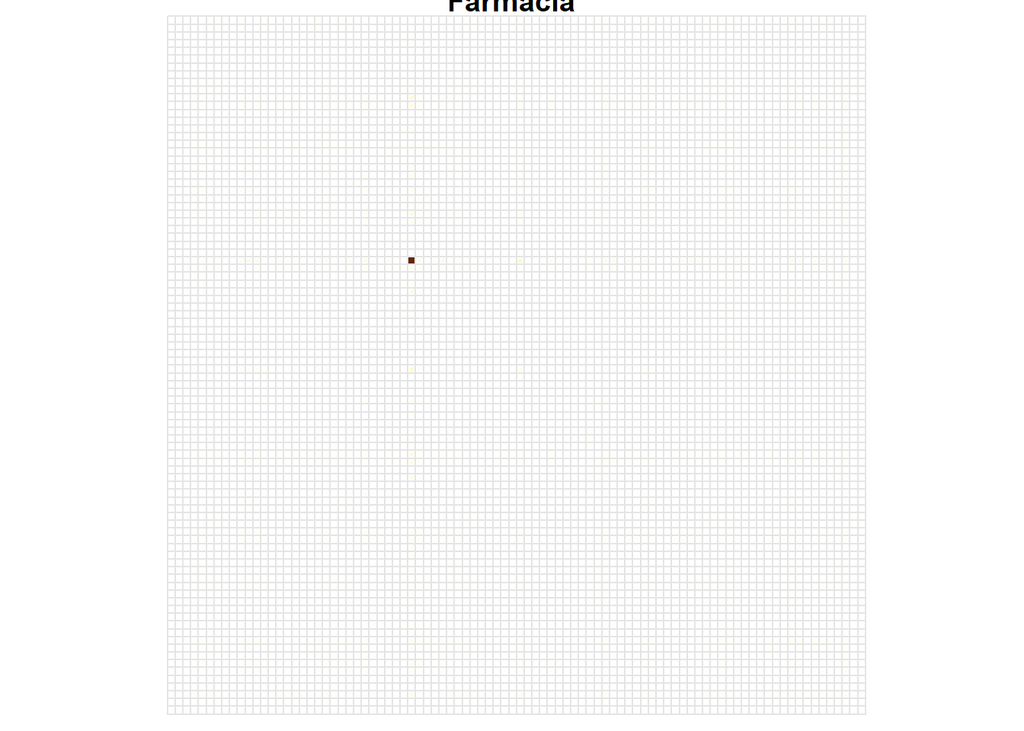

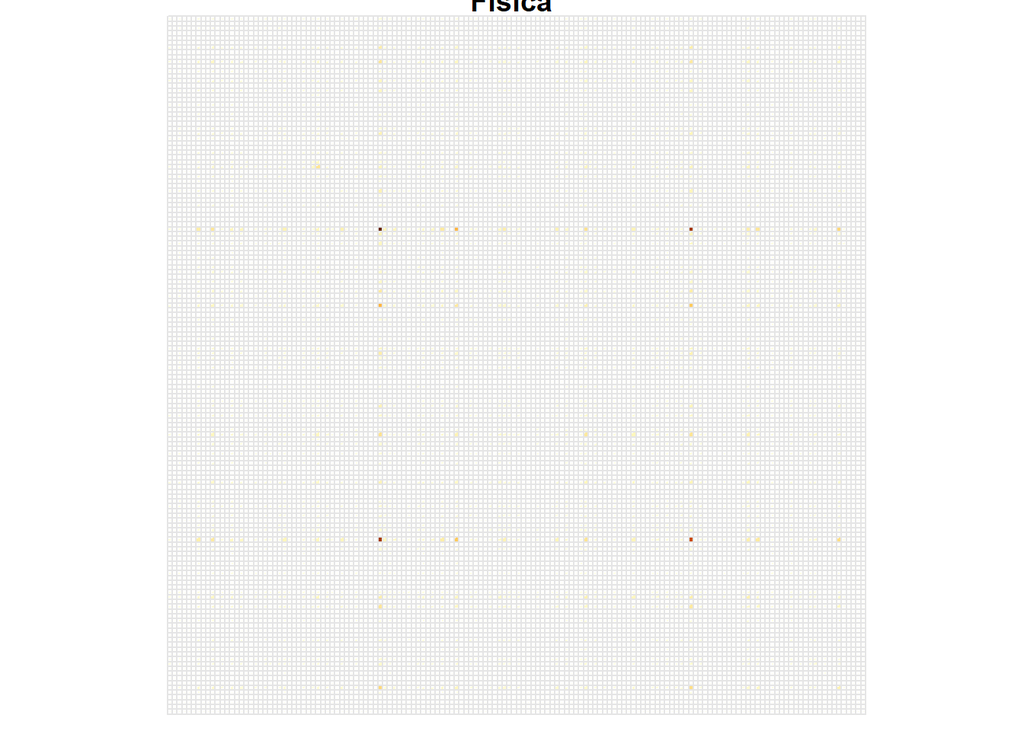

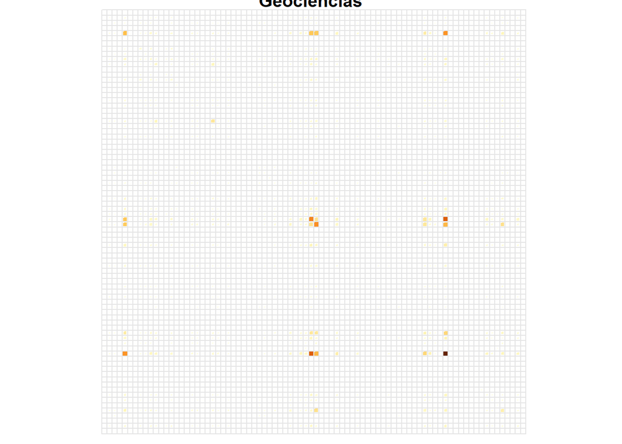

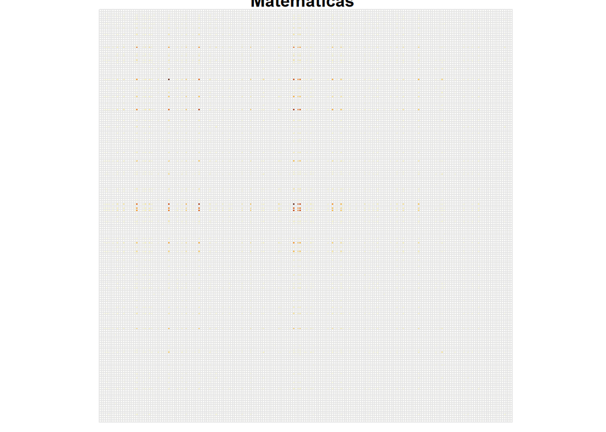

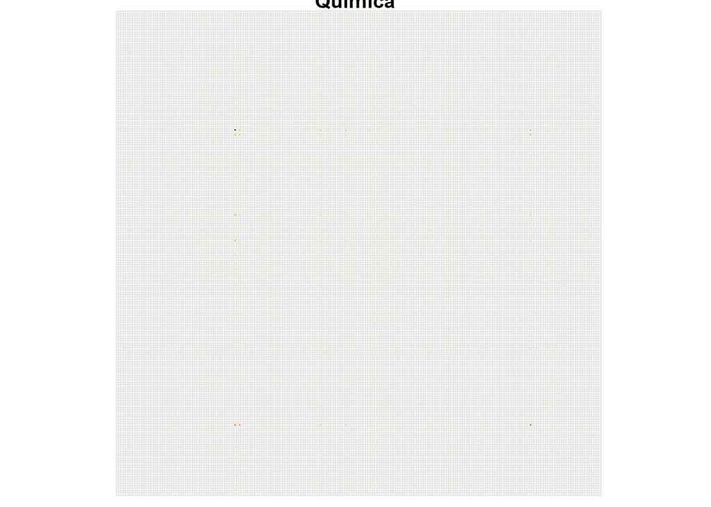

## c. Crear visualizaciones detalladas y decoradas de todas las redes, destacando sus características clave. Presentar los resultados en un formato comparativo para facilitar el análisis de similitudes y diferencias entre las redes.

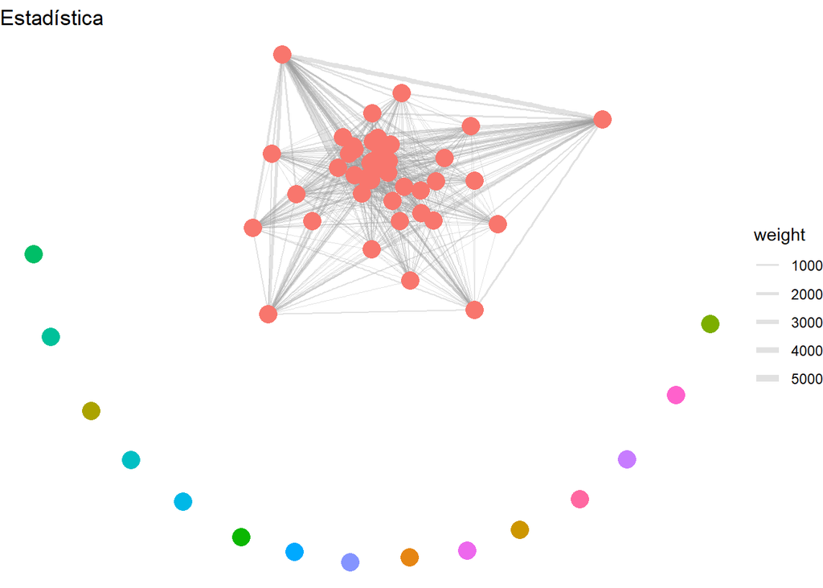

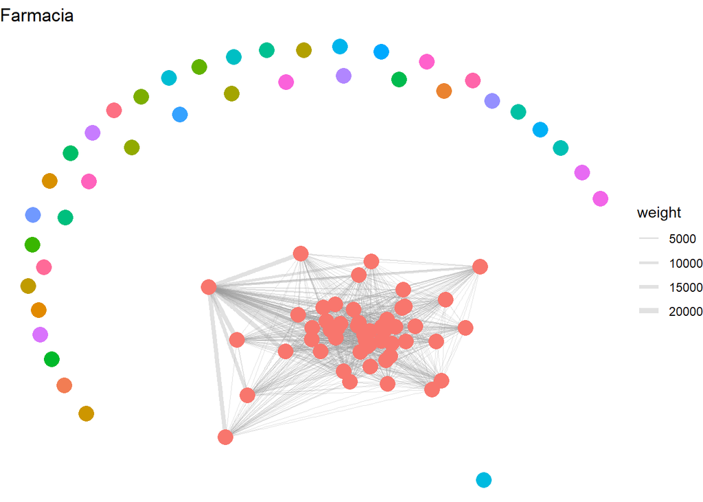

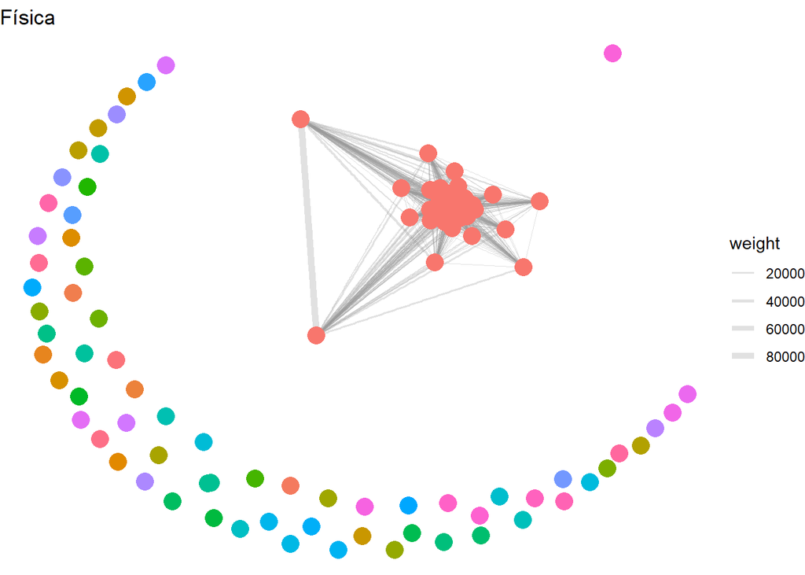

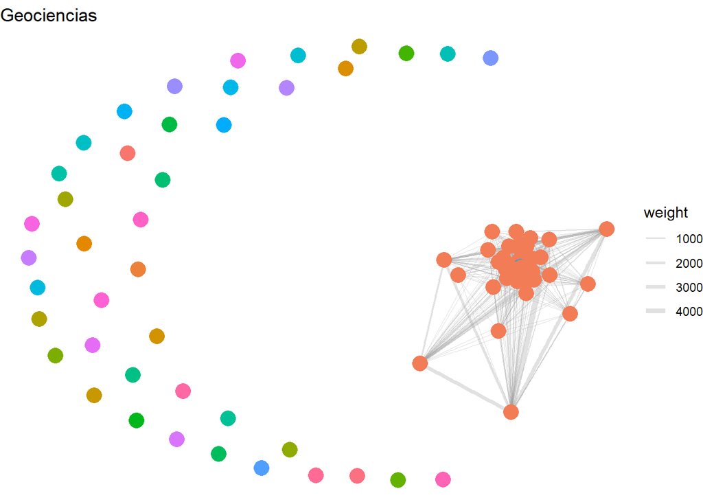

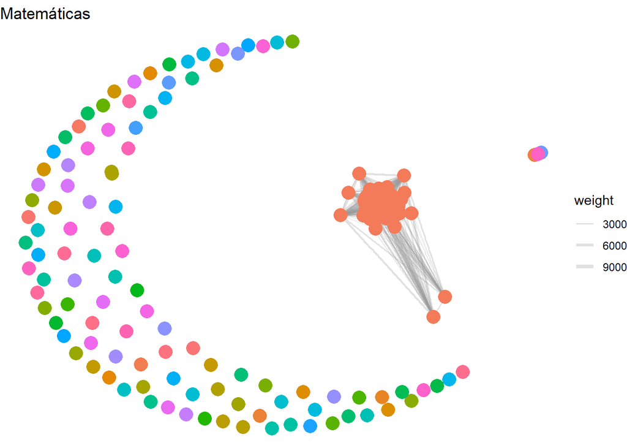

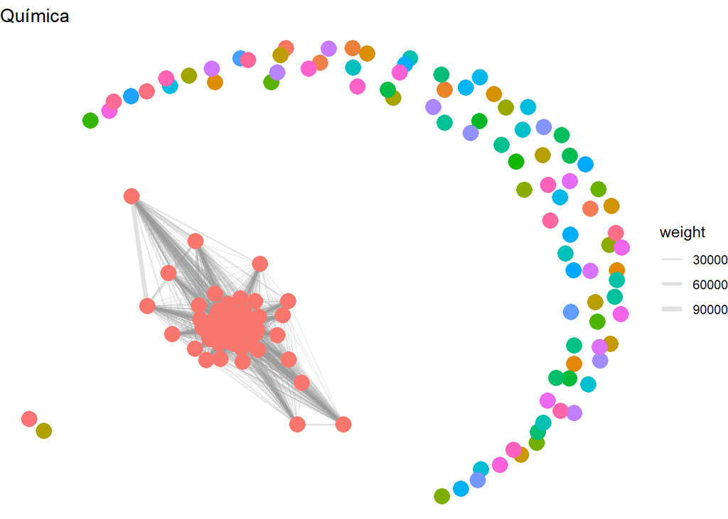

## d. Caracterizar cada una de las redes a nivel local y estructural, considerando métricas como la distancia, la centralidad, la cohesión, la conectividad y el agrupamiento. Utilizar todas las métricas disponibles para proporcionar un análisis exhaustivo de las propiedades de cada red.

### Distancia

Resultados

| Medidas.departamento | Estadística | Farmacia | Física | Geociencias | Matemáticas | Química |
| --- | --- | --- | --- | --- | --- | --- |
| Orden | 58 | 90 | 146 | 82 | 192 | 210 |
| Tamano | 750 | 1082 | 2691 | 552 | 2236 | 6356 |
| Orden de la componente gigante | 43 | 51 | 78 | 39 | 85 | 118 |
| Diametro del grafo | 3 | 3 | 3 | 2 | 5 | 3 |
| Camino del diametro | 2037;2078;2322;2056 | 1637;1736;1682;2144 | 1629;1788;2229;2472 | 1639;1684;1649 | 1749;1672;1721;1724;1820;1849 | 1862;1826;2509;1949 |
| distancia media | 1.22 | 1.197 | 1.154 | 1.312 | 1.491 | 1.097 |

En promedio los profesores se conectan entre sí directamente, aproximadamente.

### Centralidad

Resultados

| Medidas / Departamentos | Estadística Media | Estadística Desviacion Estandar | Farmacia Media | Farmacia Desviacion Estandar | Física Media | Física Desviacion Estandar | Geociencias Media | Geociencias Desviacion Estandar | Matemáticas Media | Matemáticas Desviacion Estandar | Química Media | Química Desviacion Estandar |
| --- | --- | --- | --- | --- | --- | --- | --- | --- | --- | --- | --- | --- |
| Grado | 0.454 | 0.306 | 0.270 | 0.255 | 0.254 | 0.248 | 0.166 | 0.189 | 0.122 | 0.157 | 0.290 | 0.267 |
| Cercania | 0.035 | 0.012 | 0.041 | 0.012 | 0.047 | 0.048 | 0.110 | 0.033 | 0.146 | 0.137 | 0.033 | 0.012 |
| Intermediacion | 0.019 | 0.053 | 0.007 | 0.021 | 0.004 | 0.017 | 0.005 | 0.016 | 0.002 | 0.008 | 0.004 | 0.015 |
| Propio | 0.160 | 0.245 | 0.017 | 0.105 | 0.041 | 0.116 | 0.049 | 0.145 | 0.053 | 0.153 | 0.031 | 0.093 |

- Como se mencionó anteriormente, Estadística presenta un grado medio más alto que el resto de los departamentos. Esto confirma que, en promedio, los profesores de Estadística tienen más conexiones directas con otros colegas, sin embargo a nivel general las desviaciones promedio son bastante dispersas con respecto al promedio.
- En términos de cercanía, en general hay valores bajos, lo que indica que los profesores en promedio no estan tan cerca unos de otros, pero se resaltan los departamentos de **Geociencias** y **Matemáticas** ya que son los que poseen mayores valores medios, esto indica que, en promedio, los profesores de estos departamentos están más cerca unos de otros a comparación de los demás, sin embargo, el departamento de Geociencias es más estable pues presenta una desviación estandár menor.
- Para la intermediación podemos notar que en general en promedio no hay profesores que actuen como intermediarios de otros, sin embargo tambien podemos notar que hay una gran variabilidad de las medidas en estos departamentos.
- Para la centralidad propia, Estadística nuevamente presenta un valor más alto que los otros departamentos, lo que nos en indica que en promedio los profesores suelen conectarse con otros profesores que a su vez han trabajado con muchos colegas más, sin embargo la variablidad de esta medida promedio sigue siendo elevada para todos los departamentos.

### Cohesión

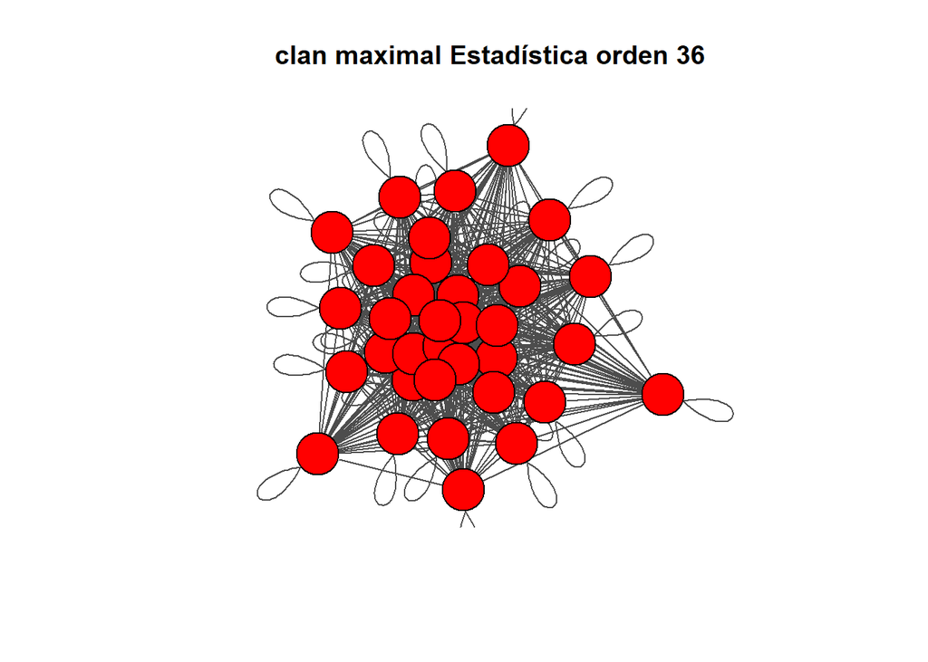

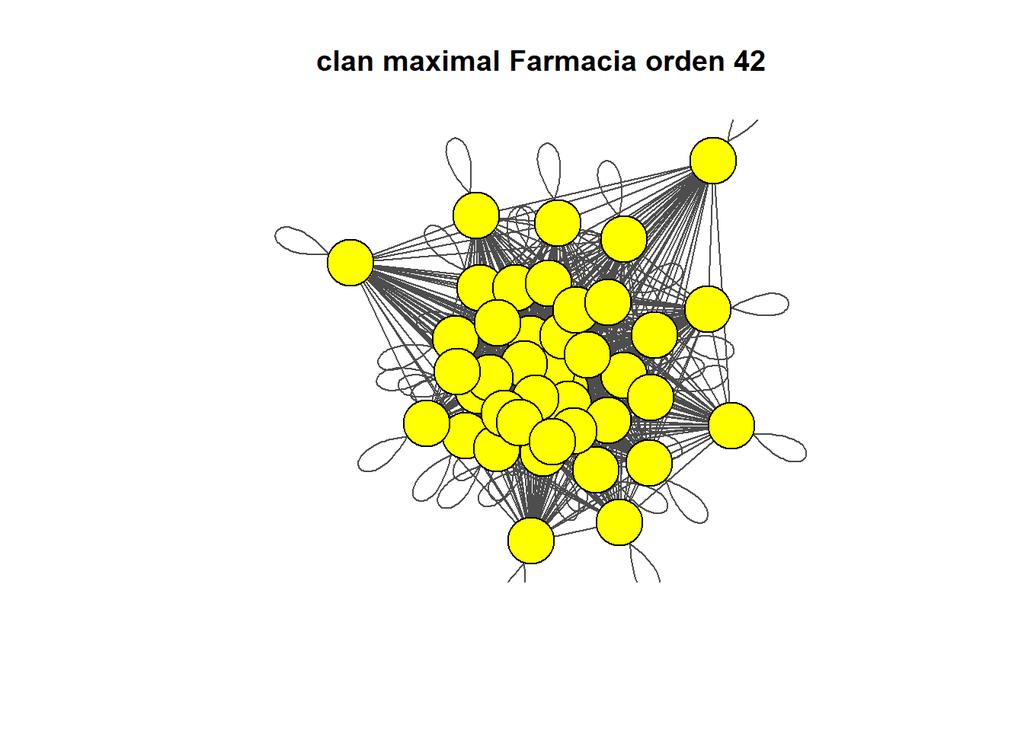

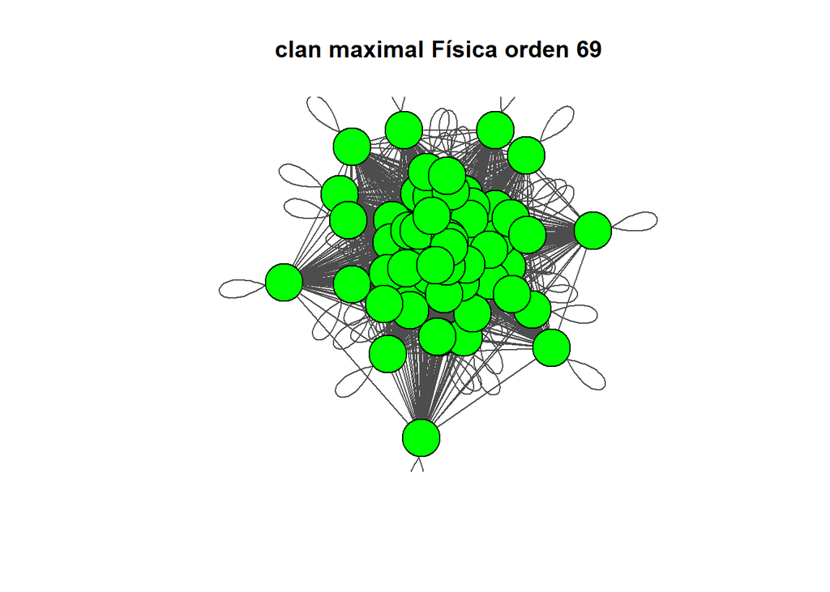

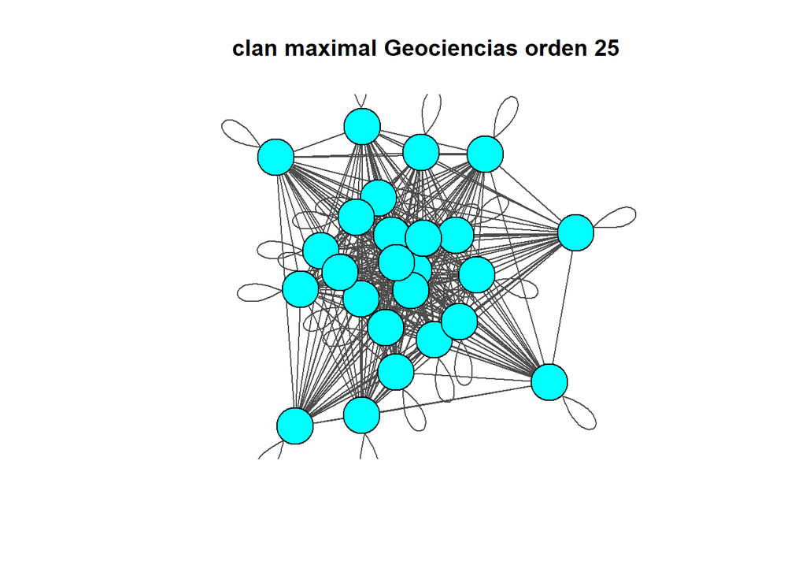

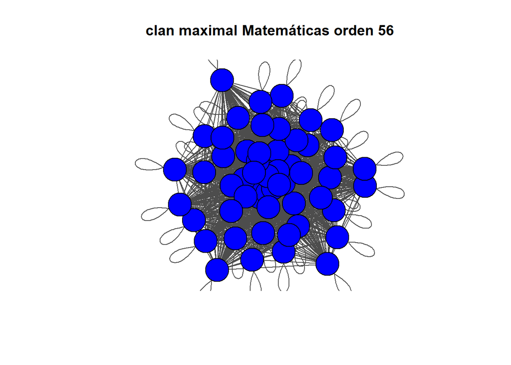

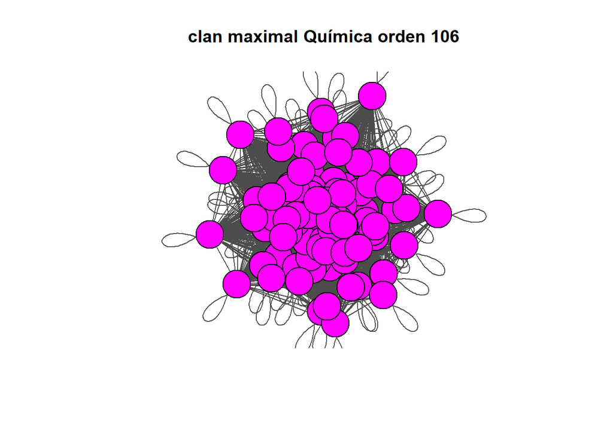

Clanes y su Frecuencia para Estadística

| Tamano clique | cantidad de cliques |
| --- | --- |
| 1 | 15 |
| 5 | 2 |
| 8 | 2 |
| 10 | 1 |
| 12 | 1 |
| 13 | 1 |
| 14 | 1 |
| 15 | 2 |
| 36 | 1 |

Clanes y su Frecuencia para Farmacia

| Tamano clique | cantidad de cliques |
| --- | --- |
| 1 | 39 |
| 2 | 1 |
| 7 | 2 |
| 14 | 1 |
| 18 | 1 |
| 19 | 1 |
| 23 | 4 |
| 27 | 2 |
| 29 | 2 |
| 36 | 1 |
| 42 | 1 |

Clanes y su Frecuencia para Física

| Tamano clique | cantidad de cliques |
| --- | --- |
| 1 | 66 |
| 2 | 2 |
| 10 | 2 |
| 11 | 1 |
| 12 | 3 |
| 14 | 2 |
| 16 | 1 |
| 18 | 1 |
| 25 | 1 |
| 37 | 2 |
| 40 | 2 |
| 41 | 1 |
| 42 | 1 |
| 44 | 1 |
| 62 | 1 |
| 69 | 1 |

Clanes y su Frecuencia para Geociencias

| Tamano clique | cantidad de cliques |
| --- | --- |
| 1 | 43 |
| 3 | 1 |
| 6 | 3 |
| 7 | 1 |
| 9 | 3 |
| 12 | 1 |
| 13 | 2 |
| 22 | 5 |
| 23 | 2 |
| 25 | 1 |

Clanes y su Frecuencia para Matemáticas

| Tamano clique | cantidad de cliques |
| --- | --- |
| 1 | 105 |
| 2 | 3 |
| 3 | 2 |
| 4 | 1 |
| 5 | 4 |
| 6 | 3 |
| 11 | 2 |
| 12 | 1 |
| 13 | 4 |
| 14 | 3 |
| 16 | 1 |
| 17 | 1 |
| 18 | 1 |
| 20 | 2 |
| 21 | 2 |
| 22 | 3 |
| 23 | 5 |
| 24 | 3 |
| 25 | 5 |
| 26 | 6 |
| 27 | 8 |
| 28 | 6 |
| 29 | 4 |
| 30 | 4 |
| 31 | 3 |
| 32 | 3 |
| 33 | 6 |
| 34 | 5 |
| 35 | 3 |
| 36 | 1 |
| 37 | 1 |
| 38 | 2 |
| 41 | 1 |
| 56 | 1 |

Clanes y su Frecuencia para Química

| Tamano clique | cantidad de cliques |
| --- | --- |
| 1 | 92 |
| 2 | 1 |
| 13 | 1 |
| 14 | 1 |
| 15 | 1 |
| 41 | 1 |
| 48 | 1 |
| 53 | 1 |
| 60 | 1 |
| 61 | 4 |
| 82 | 1 |
| 83 | 2 |
| 85 | 4 |
| 94 | 1 |
| 96 | 2 |
| 102 | 1 |
| 104 | 1 |
| 106 | 1 |

Densidad de las componentes gigantes de los departamentos

|  | Estadística | Farmacia | Física | Geociencias | Matemáticas | Química |
| --- | --- | --- | --- | --- | --- | --- |
| Densidad | 0.829 | 0.849 | 0.894 | 0.741 | 0.625 | 0.921 |

Comparando los clanes maximales con las componentes anteriormente encontradas, podemos notar que para todos los departamentos casi llegan a coincidir, es decir que cubren más de la mitad de la componente gigante.

Podemos notar que los departamentos tienen componentes bastante densas siendo los de menor densidad **Matemáticas** y **Geociencias**.

### Conectividad

Conectividad

| Medidas | Estadística | Farmacia | Física | Geociencias | Matemáticas | Química |
| --- | --- | --- | --- | --- | --- | --- |
| ¿Está conectado | FALSE | FALSE | FALSE | FALSE | FALSE | FALSE |
| Conectividad nodal | 0 | 0 | 0 | 0 | 0 | 0 |
| Conectividad por aristas | 0 | 0 | 0 | 0 | 0 | 0 |
| Puntos de artículación |  | 2347 | 2229 |  | 1820;2381 | 2509 |

Ninguno de los departamentos presentó una red completamente conexa, lo cual era esperado debido a la presencia de profesores aislados o sin colaboraciones registradas. Sin embargo, las componentes gigantes mostraron estructuras densas y altamente cohesionadas. A pesar de ello, la existencia de puntos de articulación indica que ciertos profesores cumplen un papel estructural crítico, ya que su eliminación fragmentaría la red en componentes desconectadas.

### Agrupamiento

Transitividad global

|  | Estadística | Farmacia | Física | Geociencias | Matemáticas | Química |
| --- | --- | --- | --- | --- | --- | --- |
| Transitividad global | 0.926 | 0.93 | 0.957 | 0.863 | 0.873 | 0.972 |

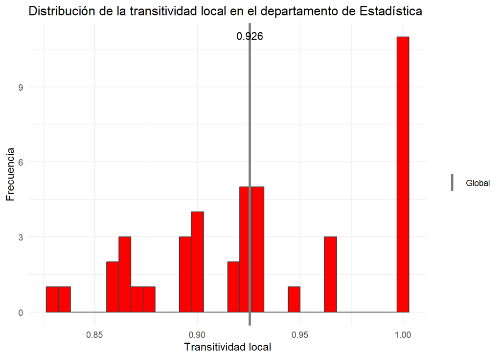

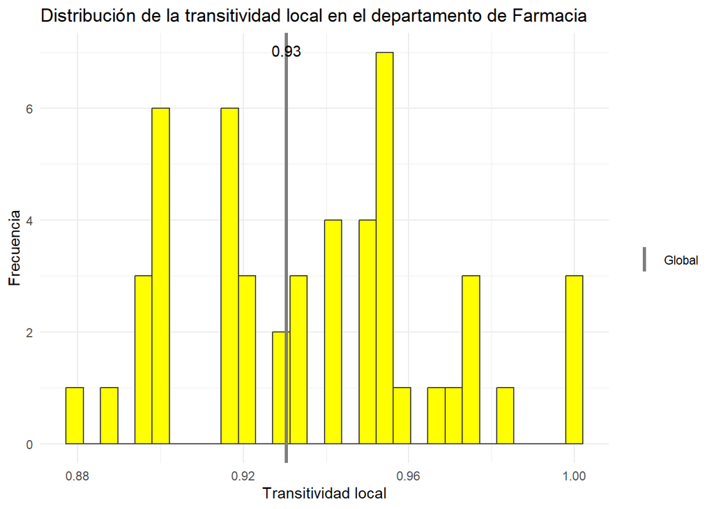

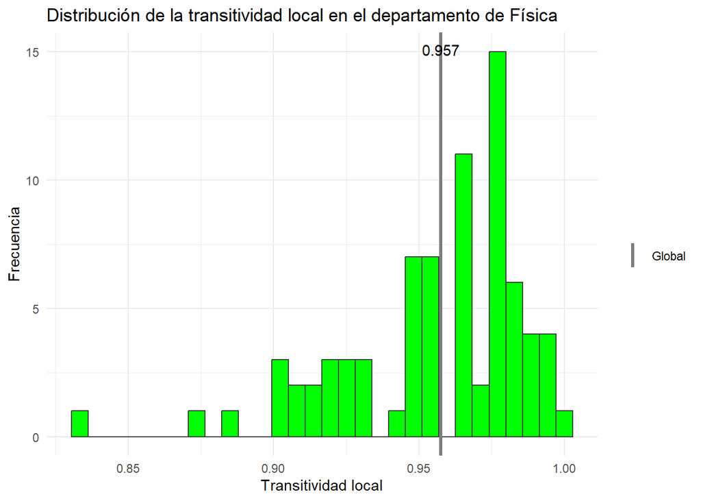

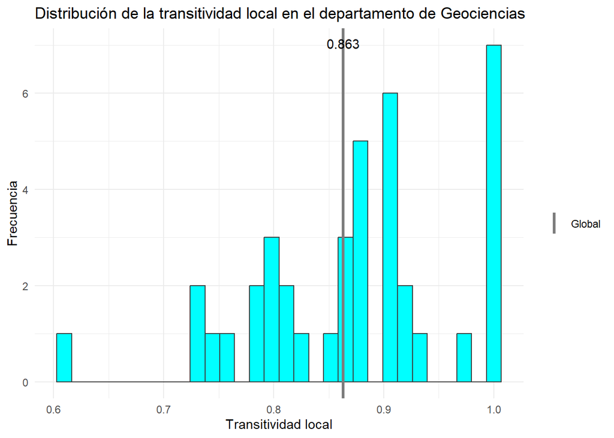

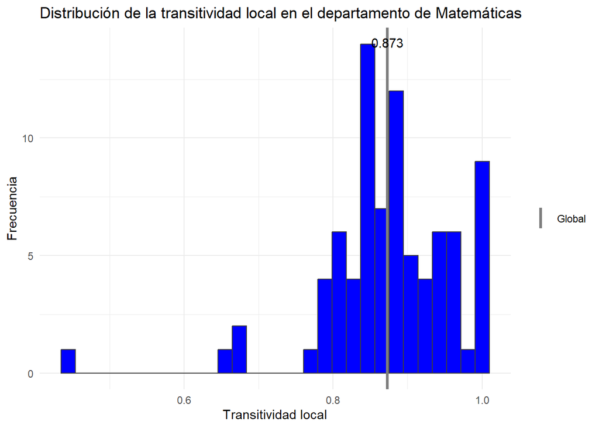

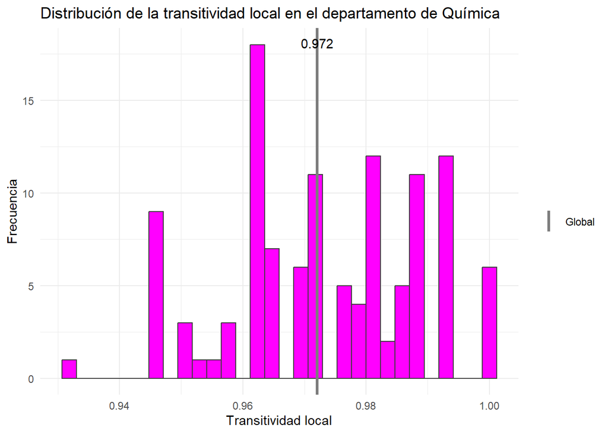

En general en los distintos departamentos notamos que, hay bastantes conexiones entre 3 profesores, es decir, que cuando dos profesores han colaborado con un tercero en común, es muy probable que también hayan colaborado directamente entre sí. En general este tipo de conectividad global esta por encima de 0.8.

En la mayoría presentan una distribución de transitividad local sesgada, lo que indica que son pocos los profesores que no han trabajado entre sí teniendo un tercero en común.

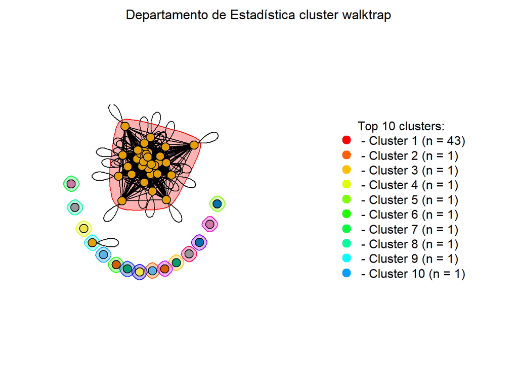

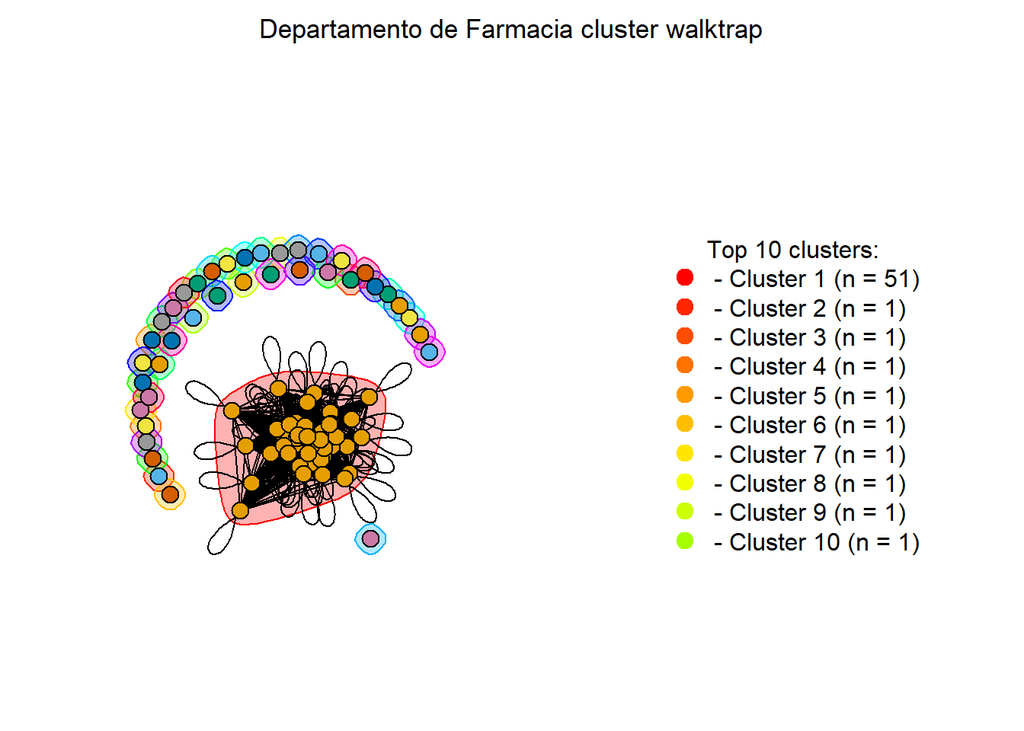

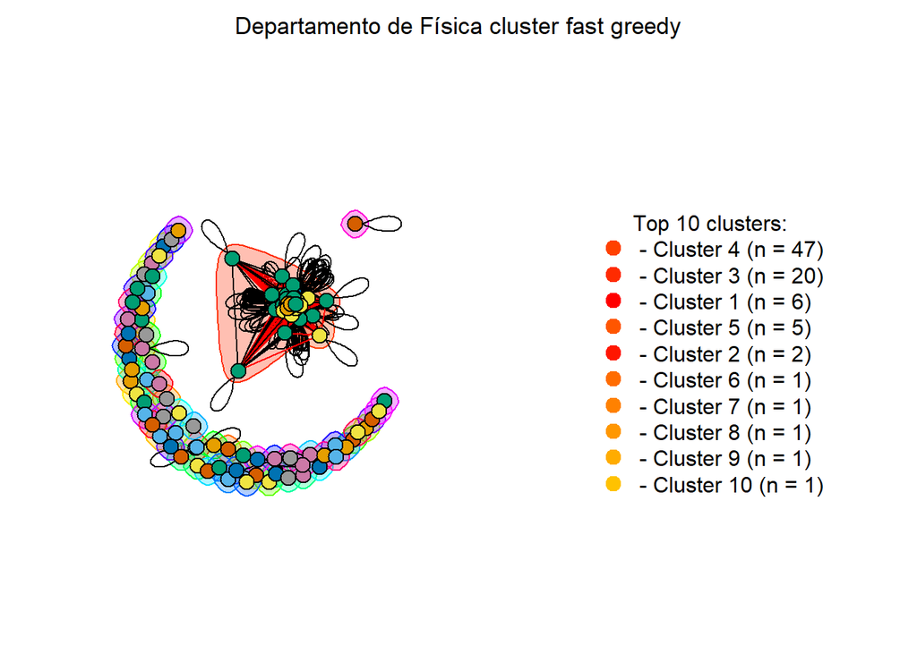

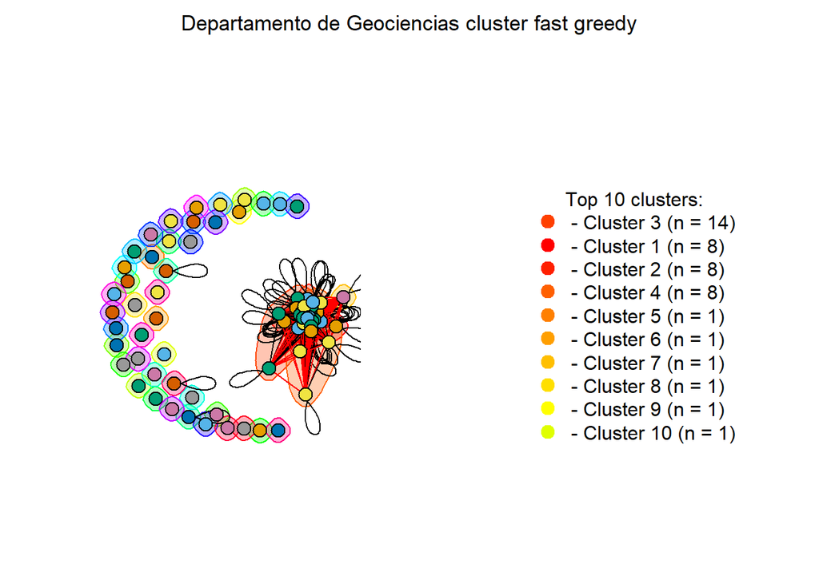

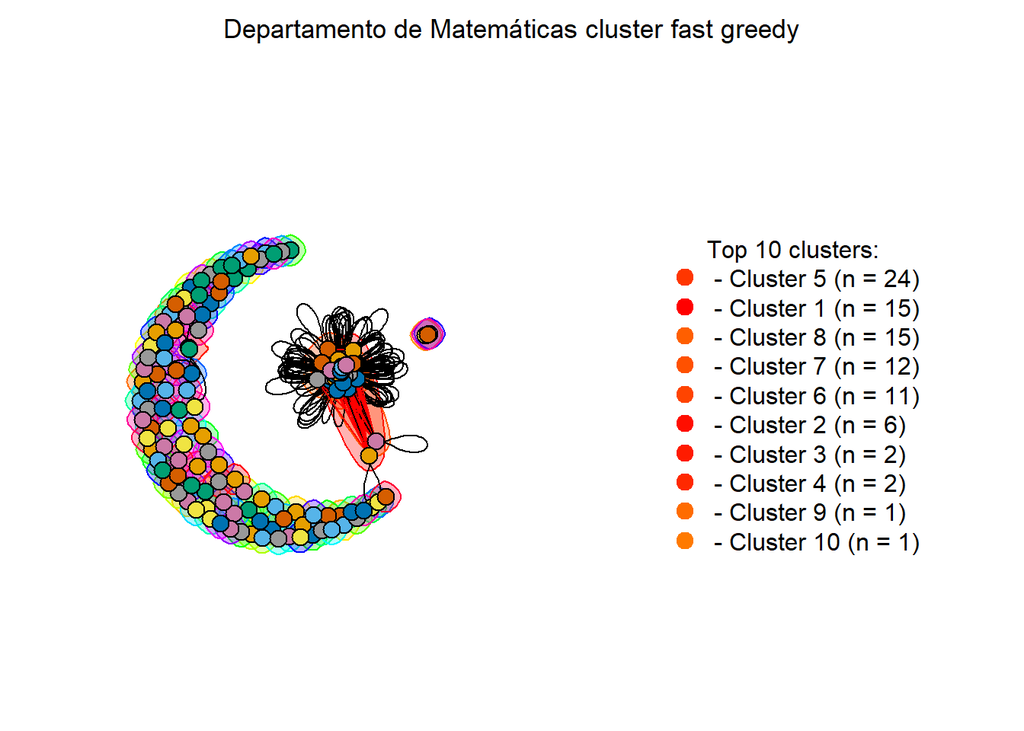

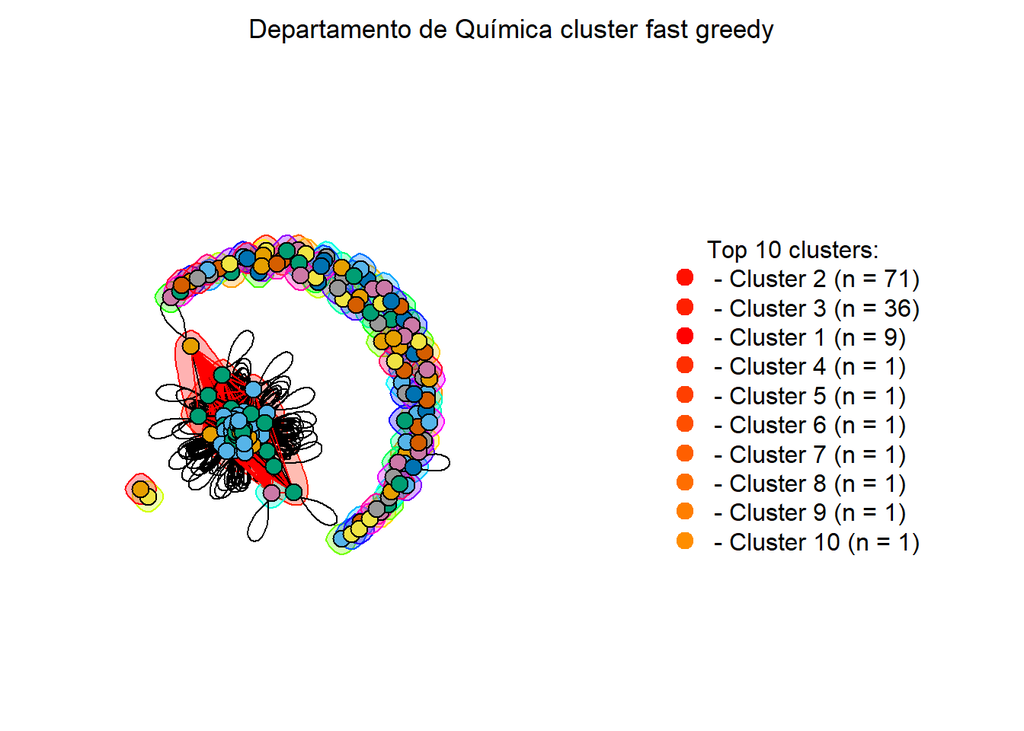

Para los departamentos de **Estadística** y **Farmacia**, el mejor algoritmo fue **Walktrap**. Este algoritmo produce una estructura de comunidades donde:

- La componente gigante se agrupa como un solo cluster (una única comunidad).
- El resto de los nodos (docentes aislados) quedan como clusters individuales o nodos no asignados a la comunidad principal.

Esto indica que, en estos departamentos, la componente gigante es altamente cohesiva y homogénea, sin subgrupos claramente diferenciados en su interior. Todos los docentes que pertenecen a la red colaborativa principal forman una única comunidad.

Por otro lado para los otros departamentos el mejor algoritmo fue **Fast Greedy**. A diferencia de Walktrap, este algoritmo sí detecta distintas agrupaciones dentro de la componente gigante. Esto significa que, en estos departamentos, aunque existe una componente gigante que conecta a la mayoría de los docentes, no es homogénea. En su interior se distinguen varias comunidades o subgrupos de profesores que colaboran más intensamente entre sí que con el resto de la componente.

## e. Repetir el análisis para toda la sede Bogotá.

## f. Interpretar los hallazgos obtenidos.

Debido a la alta densidad de conexiones presentes en la red de colaboración de la sede Bogotá, se realizó un filtrado de aristas con fines exclusivamente visuales. Para cada nodo se conservaron únicamente las tres conexiones con mayor peso, entendiendo el peso como la intensidad de colaboración entre profesores. Este procedimiento permitió reducir la sobreposición de aristas y mejorar la interpretabilidad de la estructura general de la red, preservando las relaciones más representativas de cada profesor.

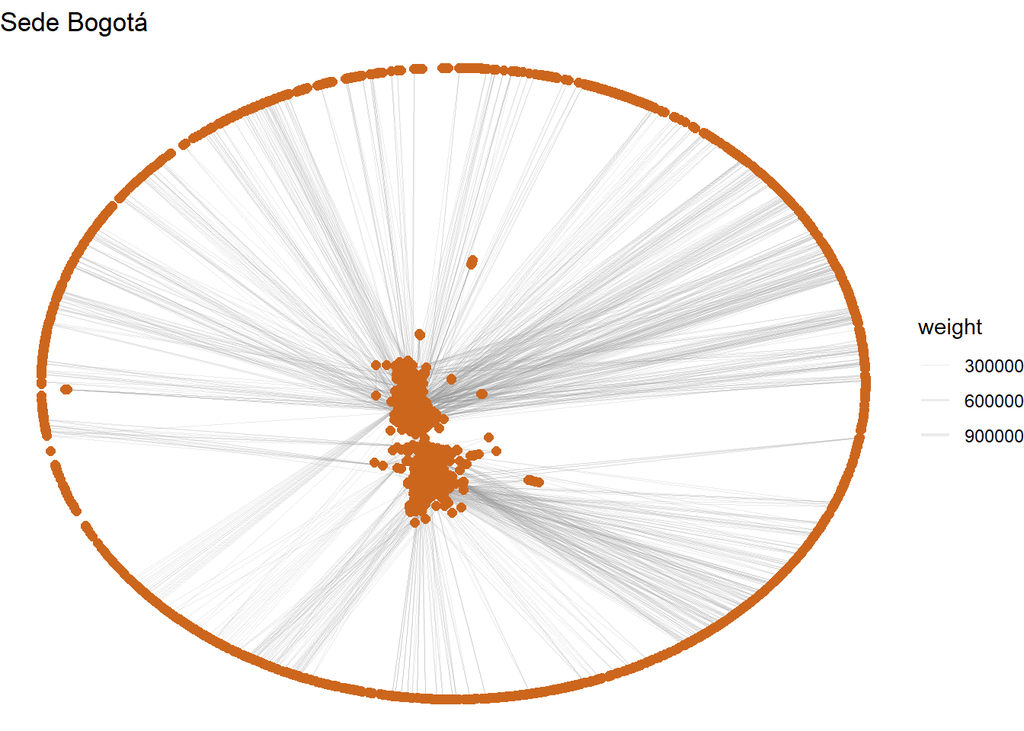

Aun después del filtrado, la red presenta una alta concentración de conexiones entre profesores, lo que evidencia una estructura de colaboración densa dentro de la sede Bogotá, también se observan nodos aislados o débilmente conectados, indicando que todavía existen profesores sin colaboraciones registradas o con baja integración dentro de la red académica.

### Distancia

Resultados

| Medidas | valor |
| --- | --- |
| Orden | 2465 |
| Tamano | 317276 |
| Orden de la componente gigante | 1530 |
| Diametro del grafo | 5 |
| Camino del diametro | 691;39;525;2255;1820;1849 |
| distancia media | 1.856 |

Se observa que la red de la sede es bastante densa, esto debido a que su componente gigante tiene un orden de 1530 nodos, mientras que la red total del departamento es de 2465 nodos, es decir cubre más de la mitad de los profesores. Adicionalmente, su diámetro indica que, a lo sumo, dos profesores se conectan a través de otros 4 profesores como máximo, esto refleja una estructura bastante compacta.

En promedio los profesores se conectan entre sí por otro profesor, aproximadamente.

### Centralidad

Resultados

| Medidas | Media | Desviación Estándar |
| --- | --- | --- |
| Grado | 0.104 | 0.116 |
| Cercanía | 0.146 | 0.045 |
| Intermediación | 0.000 | 0.001 |
| Propio | 0.001 | 0.021 |

### Cohesión

Resultados

| Tamaño de la componente | Frecuencia |
| --- | --- |
| 1 | 935 |
| 1530 | 1 |

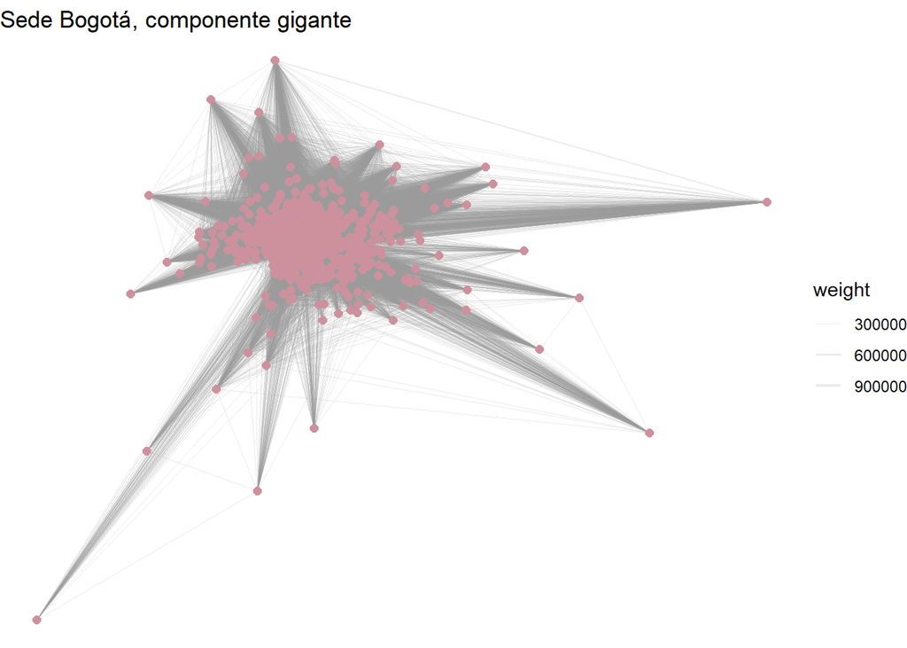

Como se mencionó anteriormente, la existencia de una componente gigante, y multiples componentes de nodos aislados, teniendo un total de 936 componentes.

### Conectividad

Conectividad

| Medidas | Valores |
| --- | --- |
| ¿Está conectado | FALSE |
| Conectivdidad nodal | 0 |
| Conectividad por aristas | 0 |
| Puntos de artículación | 1820 |

Como se sabe, existen puntos aislados, por lo que la red de profesores de toda la sede no es conectada, sin embargo dentro de la componente gigante existe un profesor con un papel crítico que al ser retirado puede generar la fragmentación de esa componente.

### Agrupamiento

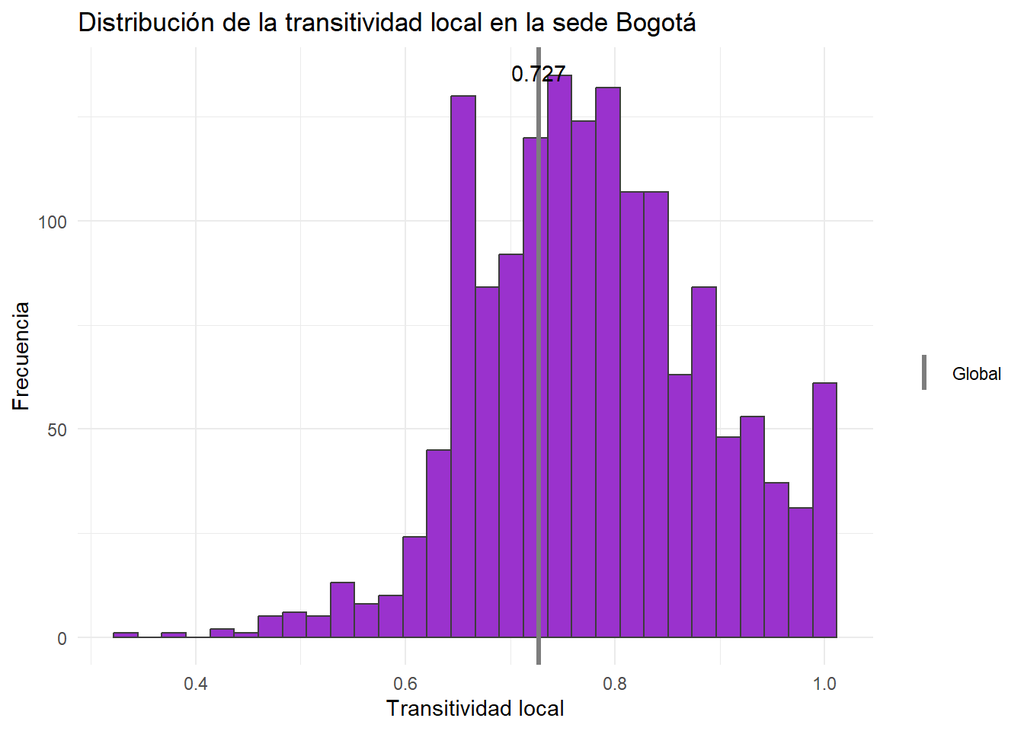

Se ve una clara distribución sesgada a izquierda, además la transitvidad global fue de 0.7 aproximadamente, esto indica que entre dos profesores con un tercero en común es bastante probable que hayan colaborado entre sí. Son pocos los profesores que no cumplen con esta descripción y y hay una alta agrupación de profesores que sí cumplen con esto.

A continuación se hizo visualizaciones de las agrupaciones de nodos no aislados por el que fue el mejor algoritmo, **Fast Greedy**, en distintos gráficos, esto no significa que no esten conectadas entre sí estas agrupaciones, y si hizo esto netamente para una mejor visualización

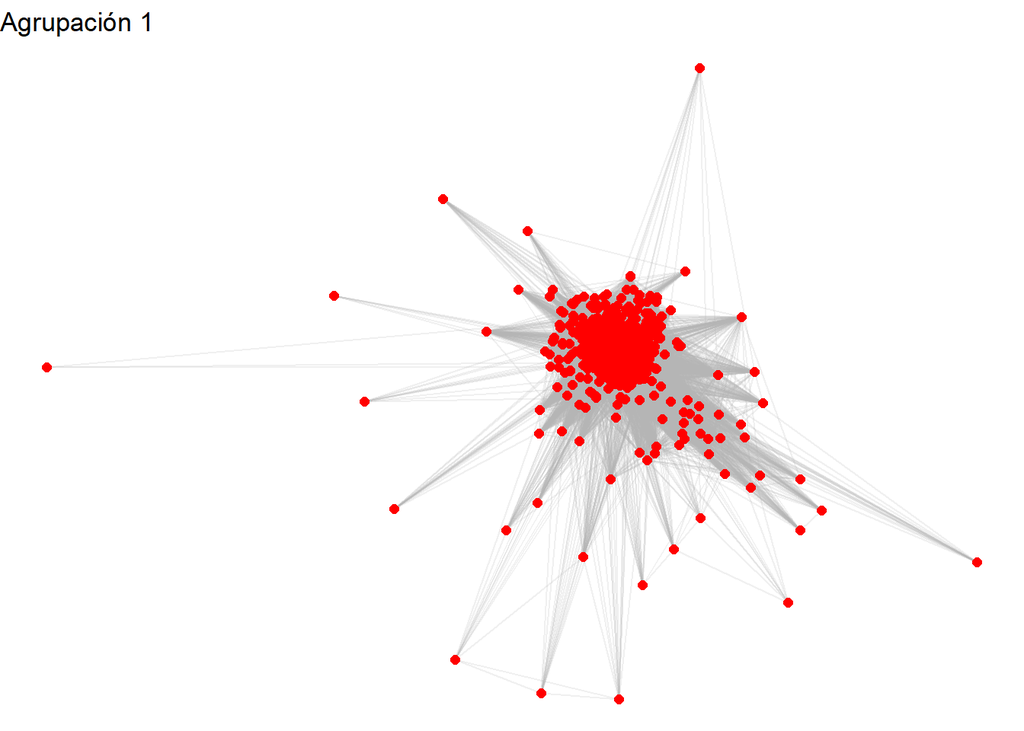

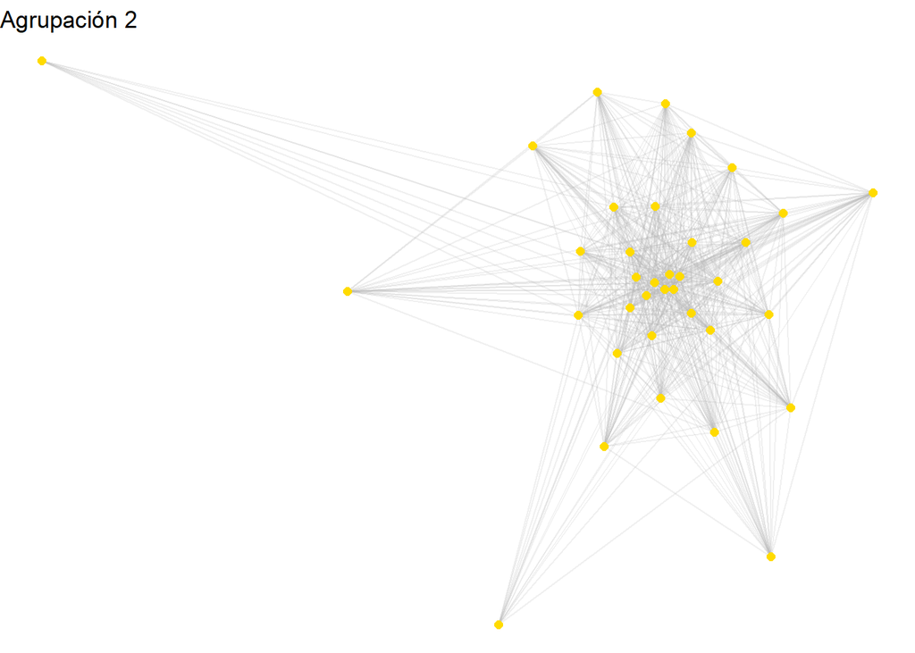

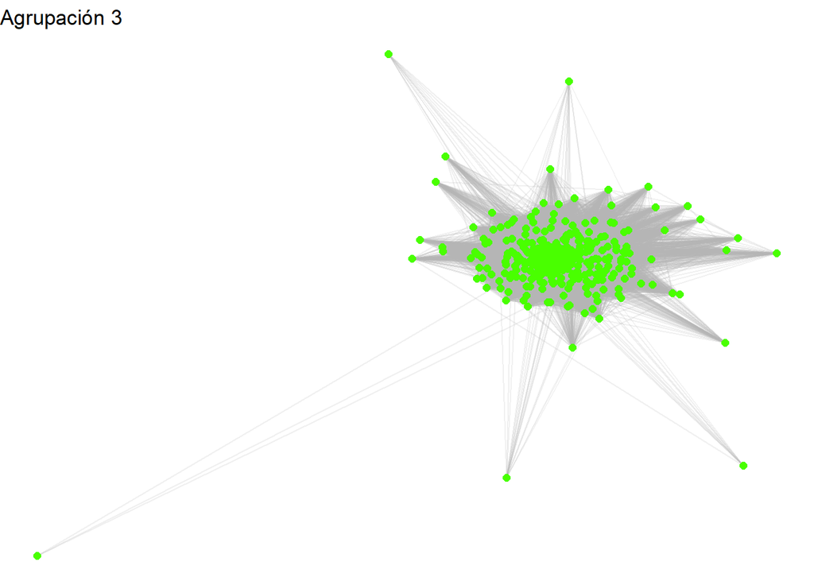

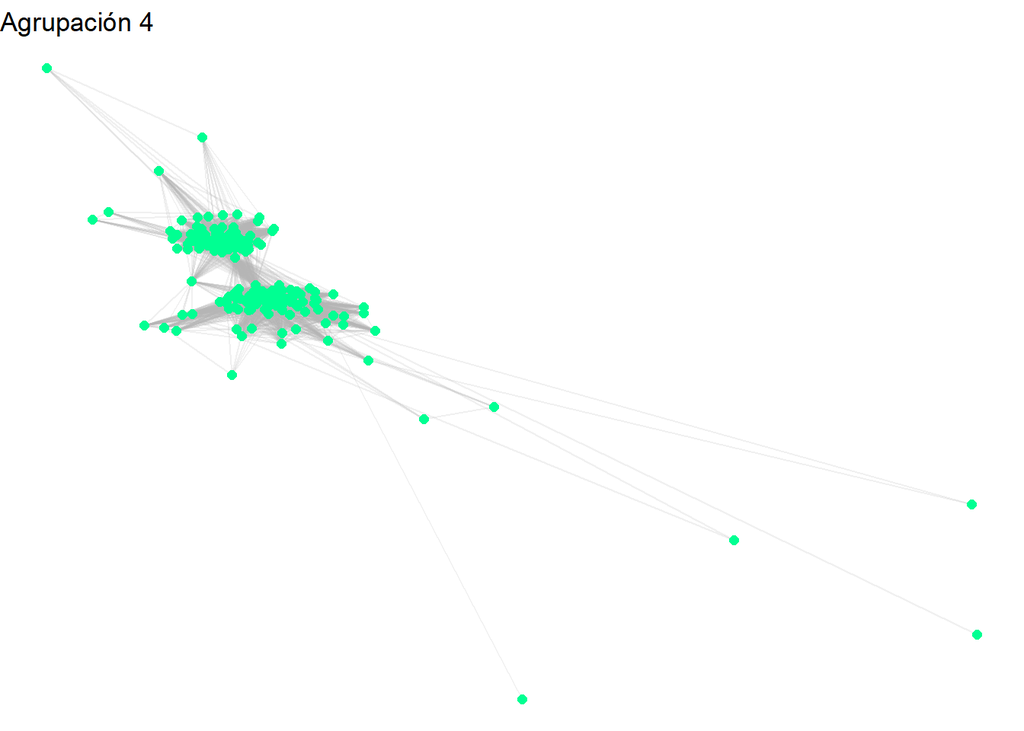

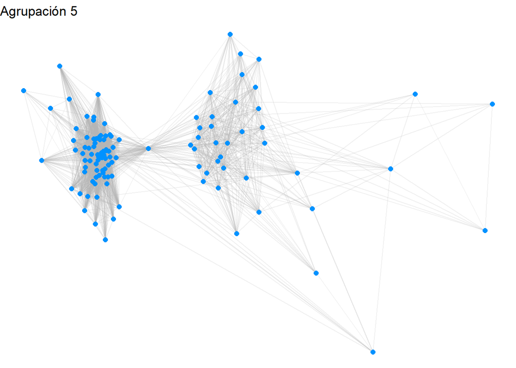

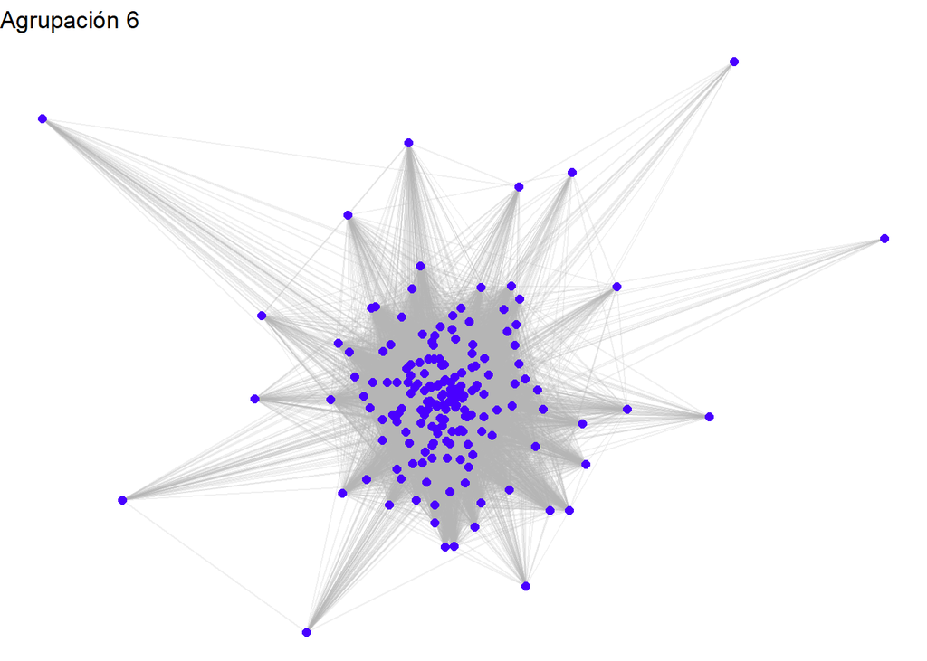

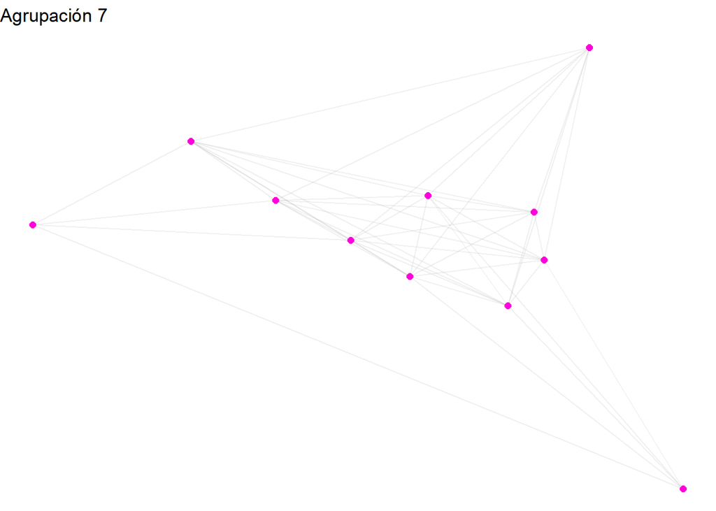

Podemos ver agrupaciones bastante densas, pero no parecen clanes, es decir que no parecen grafos completos.

Por otro lado la ultima agrupacion cuenta con muchísimos menos nodos que las anteriores, sin embargo sigue sin ser un subgrafo completo

# 3.

Este caso se basa en la preimpresión del artículo A Network-Based Approach to Characterize Twenty-First-Century Populism in Colombia (García-Arteaga y Pellegrino, 2021). El artículo aborda el populismo como “un fenómeno político de antiliberalismo democrático centrado en la figura de un líder fuerte” y realiza, entre otros aspectos, una revisión del populismo y su contexto en Colombia, destacando la posición e influencia de Álvaro Uribe como líder populista. Para ello, se analizan las conexiones de figuras prominentes del panorama político colombiano reciente, considerando relaciones de trabajo, alianzas, rivalidades, amistades y vínculos familiares, contenidas en los archivos nodes.csv. Según la Sección 2 del artículo, los datos fueron recolectados mediante herramientas de web scraping de la sección “Quién es quién” del medio colombiano independiente La Silla Vacía. El análisis identifica que las redes de trabajo (work-edges.csv) y de alianzas (alliance-edges.csv) son las más relevantes, y sus componentes conexas constituyen la principal fuente de información para el estudio.

## a. Analizar cada una de las redes tanto a nivel local como estructural, utilizando métricas como distancia, centralidad, cohesión, conectividad y agrupamiento. Emplear todas las métricas disponibles para realizar un análisis detallado y completo de las características y propiedades de cada red.

## b. Interpretar los hallazgos obtenidos.

### Red de alianzas

#### Distancia

Resultados

| Medidas | valor |
| --- | --- |
| Orden | 356 |
| Tamano | 689 |
| Orden de la componente gigante | 335 |
| Diametro del grafo | 10 |
| Camino del diametro | julio-cesar-rivera-cortes;juan-carlos-martinez-sinisterra;jorge-ivan-ospina-gomez;roberto-ortiz-uruena;alvaro-uribe-velez;carlos-felipe-cordoba-larrarte;german-vargas-lleras;rosa-cotes-vives;aristides… |
| distancia media | 4.108 |

Podemos ver que la componente gigante cubre más de la mitad de la red, la existencia de una componente gigante que concentra la mayoría de los nodos sugiere una alta integración del sistema de relaciones políticas, aunque persisten actores periféricos que no participan en los principales circuitos de interacción. En términos estructurales, la distancia promedio (~4) y el diámetro (~10) sugieren una configuración tipo small-world, donde la mayoría de los actores pueden conectarse a través de pocos intermediarios, lo que facilita la difusión de información y la consolidación de coaliciones políticas.

#### Centralidad

Resultados

| Medidas | Media | Desviación Estándar |
| --- | --- | --- |
| Grado | 0.011 | 0.014 |
| Cercanía | 0.291 | 0.175 |
| Intermediación | 0.008 | 0.021 |
| Propio | 0.117 | 0.159 |

Las métricas de centralidad presentan en general medias bajas acompañadas de desviaciones estándar relativamente altas, lo que indica una fuerte heterogeneidad estructural en ambas redes. En particular, el grado promedio bajo junto con su alta dispersión sugiere una estructura tipo núcleo-periferia, donde pocos actores concentran un número significativamente mayor de conexiones. De manera similar, la centralidad de intermediación muestra una fuerte concentración en pocos nodos, lo que evidencia la presencia de actores con rol de intermediación clave en la conexión entre subgrupos. En cuanto a la cercanía, la variabilidad indica diferencias importantes en la accesibilidad global de los nodos, con actores centrales estructuralmente mucho más cercanos al resto de la red que los periféricos. Finalmente, la centralidad de eigenvector sugiere que existe una concentración moderada baja de influencia en torno a actores bien conectados dentro de la estructura general.

#### Cohesión

Resultados

| Tamaño de la componente | Frecuencia |
| --- | --- |
| 2 | 9 |
| 3 | 1 |
| 335 | 1 |

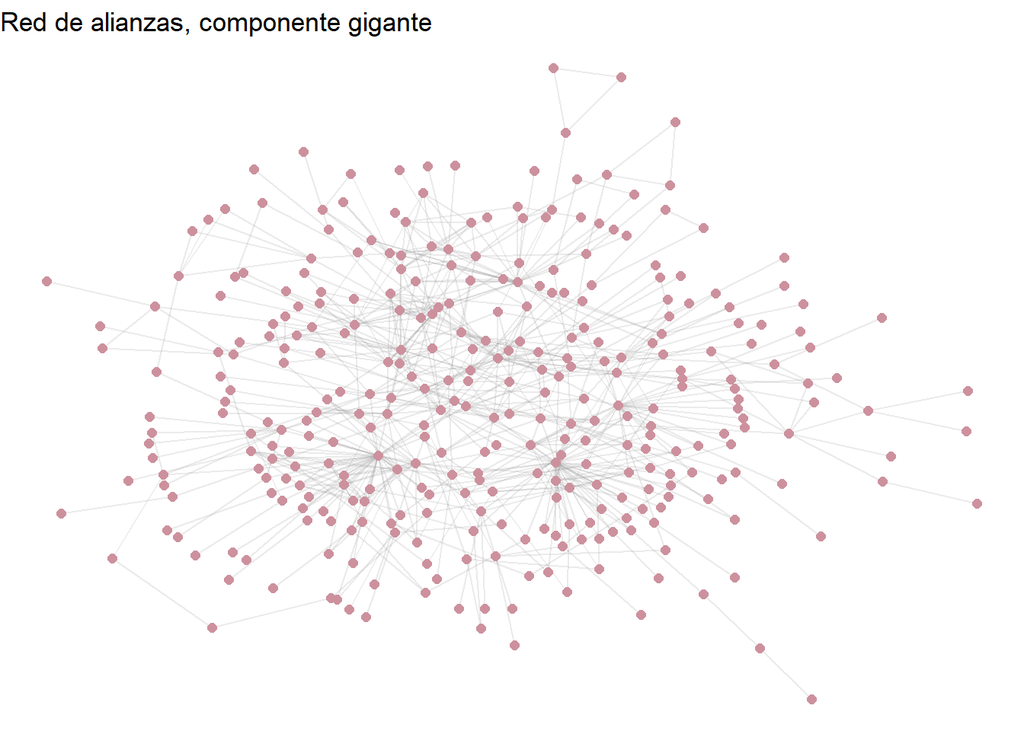

La red presenta una estructura altamente centralizada en términos de conectividad, donde una única componente gigante de 335 nodos concentra la gran mayoría de los actores. Esto indica la existencia de un núcleo altamente integrado de relaciones políticas. En contraste, se observan múltiples componentes pequeñas de tamaño 2 y una de tamaño 3, lo que evidencia la presencia de actores periféricos con relaciones limitadas a interacciones aisladas o subgrupos muy reducidos. En conjunto, la estructura sugiere un sistema político con un fuerte núcleo relacional y una periferia fragmentada, característica común en redes de élites donde la conectividad está mediada por pocos actores centrales.

#### Conectividad

Resultados

| Medidas | Valores |
| --- | --- |
| ¿Está conectado | FALSE |
| Conectivdidad nodal | 0 |
| Conectividad por aristas | 0 |
| Puntos de artículación | fabio-valencia-cossio;nancy-patricia-gutierrez;rodrigo-rivera-salazar;dilian-francisca-toro;francisco-santos-calderon;andres-felipe-arias;jose-felix-lafaurie-rivera;ernesto-samper-pizano;anibal-gaviri… |

Se identifica un conjunto amplio de nodos con potencial rol de articulación estructural dentro de la red. La presencia de múltiples actores en esta categoría sugiere que la conectividad global no depende de un único nodo crítico, sino de varios intermediarios distribuidos a lo largo de la estructura. Esto indica una red con fragilidad estructural moderada, en la cual la eliminación de ciertos actores podría incrementar significativamente la fragmentación del sistema.

#### Agrupamiento

[figure not shown]

La transitividad local presenta una moda igual a cero, lo que indica que la mayoría de los nodos se encuentran en entornos poco cohesionados, donde sus vecinos no tienden a estar conectados entre sí. Esto sugiere estructuras locales tipo estrella o relaciones dispersas sin cierre triádico frecuente. A nivel global, la transitividad de la red (0.14) es baja, lo que indica una limitada formación de triángulos y, por tanto, una baja tendencia a la formación de cliques o grupos cerrados dentro de la red. En conjunto, estos resultados sugieren una estructura relacional poco transitive, característica de redes donde predominan relaciones asimétricas o mediadas por pocos actores centrales.

A continuación se hizo visualizaciones de las agrupaciones de nodos no aislados y no de parejas de nodos, por el que fue el mejor algoritmo, **Fast Greedy**, en distintos gráficos, esto no significa que no esten conectadas entre sí estas agrupaciones, y si hizo esto netamente para una mejor visualización

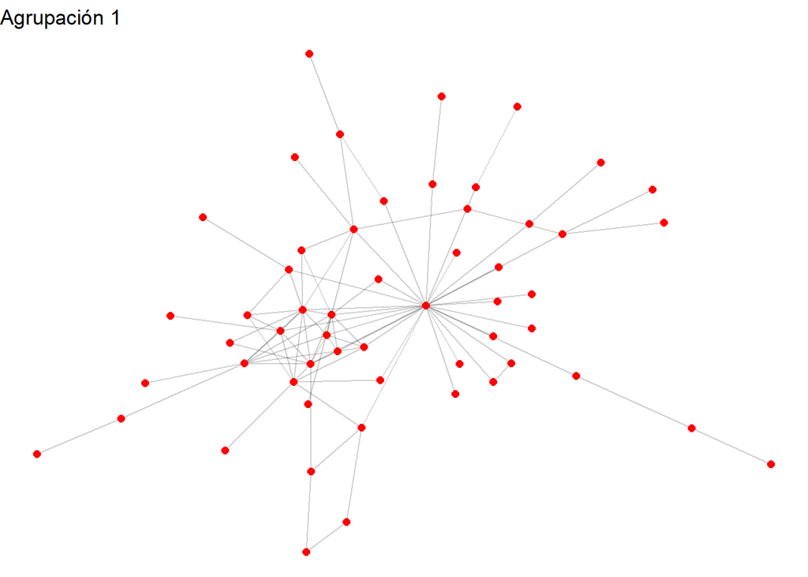

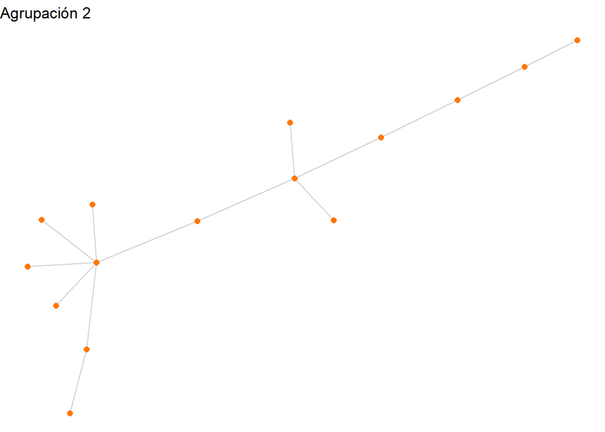

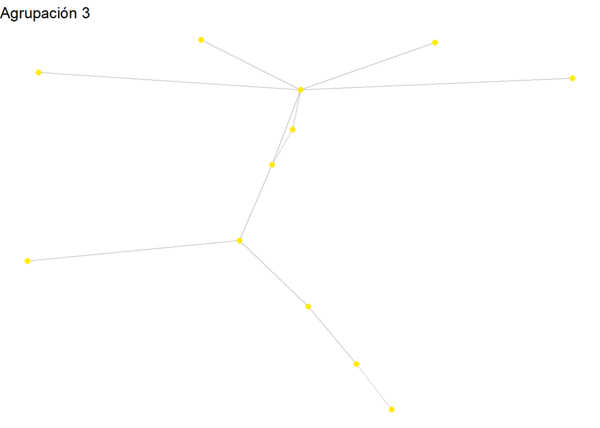

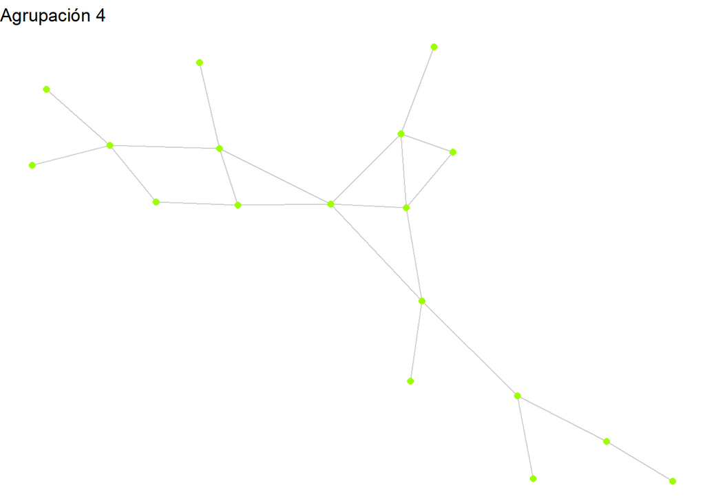

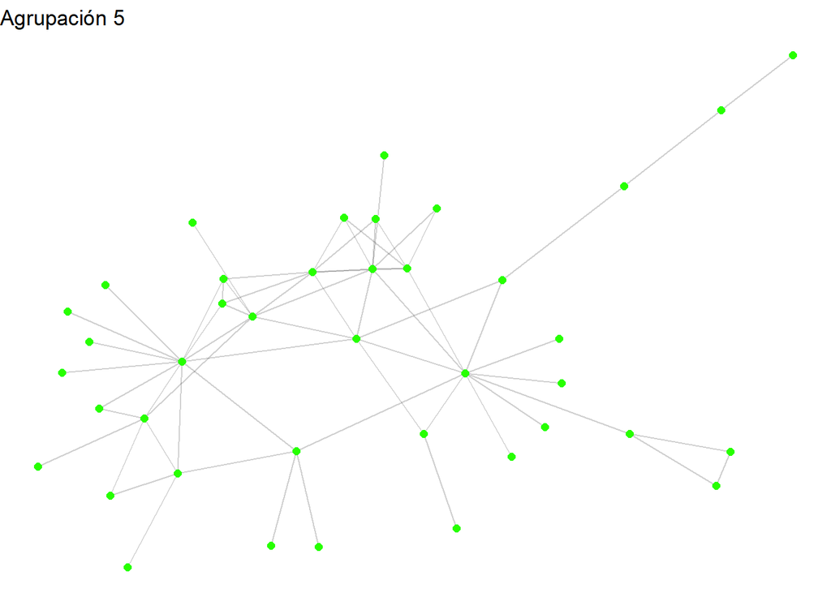

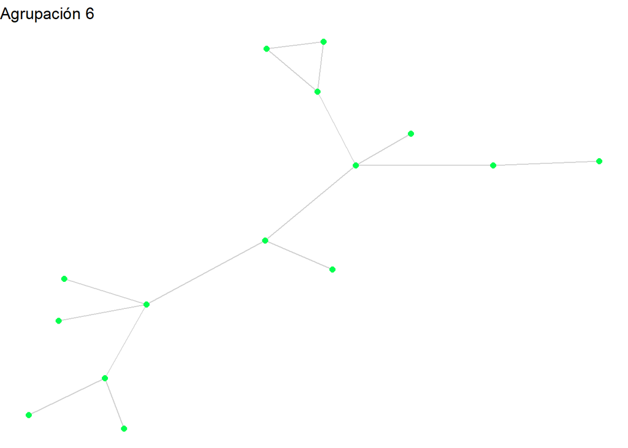

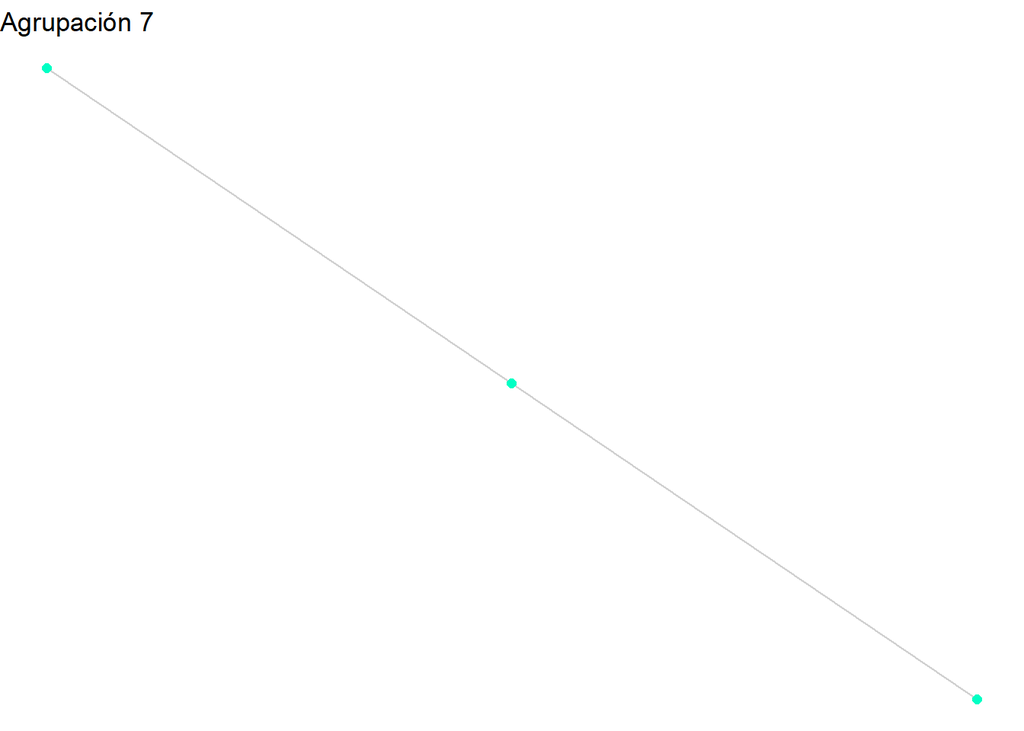

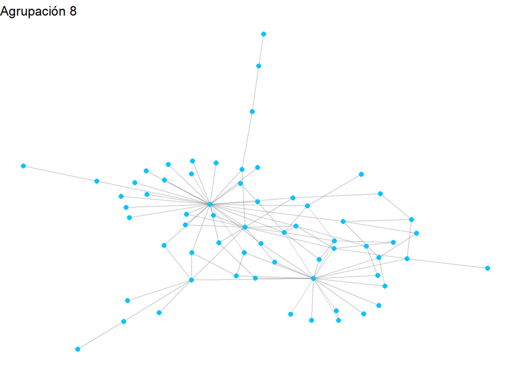

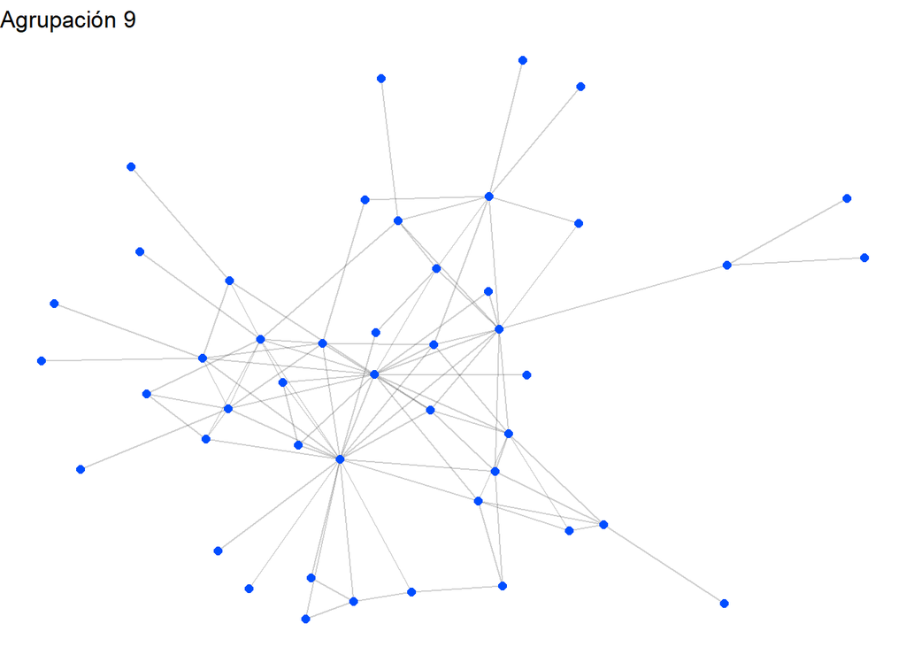

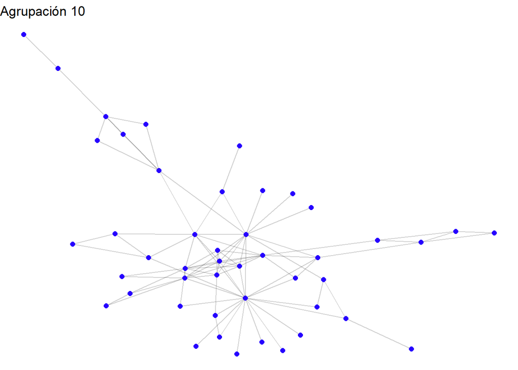

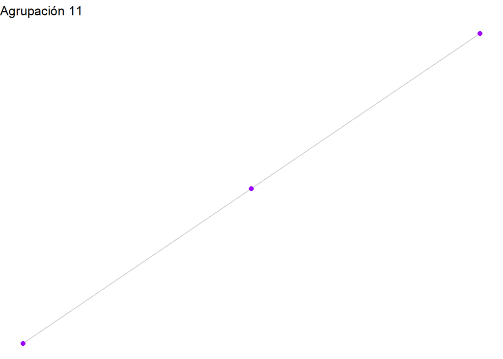

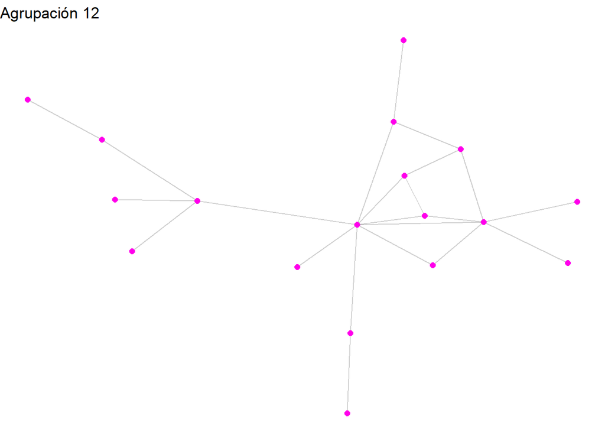

[1 more figures not shown]

Notamos grandes agrupaciones de distintos políticos.

## Red de trabajo

#### Distancia

Resultados

| Medidas | valor |
| --- | --- |
| Orden | 511 |
| Tamano | 1393 |
| Orden de la componente gigante | 485 |
| Diametro del grafo | 8 |
| Camino del diametro | daniel-samper-ospina;daniel-coronell;felipe-lopez-caballero;rodrigo-pardo-garcia-pena;nestor-humberto-martinez;yesid-reyes-alvarado;rodrigo-uprimny-yepes;gustavo-gallon-giraldo;jose-miguel-vivanco |
| distancia media | 3.308 |

Podemos ver, al igual que con la red de alianzas, que la componente gigante cubre más de la mitad de la red. En términos estructurales, la distancia promedio (~3) y el diámetro (~8) sugieren una configuración donde la mayoría de los actores pueden conectarse a través de pocos intermediarios, lo que facilita la difusión de información y la consolidación de coaliciones políticas.

#### Centralidad

Resultados

| Medidas | Media | Desviación Estándar |
| --- | --- | --- |
| Grado | 0.011 | 0.020 |
| Cercanía | 0.347 | 0.160 |
| Intermediación | 0.004 | 0.023 |
| Propio | 0.049 | 0.072 |

- Las métricas de centralidad presentan en general medias bajas acompañadas de desviaciones estándar relativamente altas, lo que indica una fuerte heterogeneidad estructural en ambas redes. En particular, el grado promedio bajo junto con su alta dispersión sugiere una estructura tipo núcleo-periferia, donde pocos actores concentran un número significativamente mayor de conexiones.
- En cuanto a la cercanía, indica actores mucho más cercanos al resto de la red que en el caso anterior de alianza, lo que facilita la circulación de información o influencia dentro de la estructura. No obstante, la desviación estándar indica la presencia de heterogeneidad en la accesibilidad, evidenciando diferencias entre actores centrales y periféricos dentro de la red.
- La centralidad de intermediación muestra una fuerte concentración en pocos nodos, lo que evidencia la presencia de actores con rol de intermediación clave en la conexión entre subgrupos.
- La centralidad de eigenvector presenta valores promedio de 0.049 en la red de trabajo y 0.117 en la red de alianzas. Esto sugiere que la estructura de alianzas tiende a concentrar en mayor medida la influencia en torno a nodos conectados a otros actores relevantes, lo que indica una organización más jerárquica de la centralidad. En contraste, la red de trabajo sugiere una menor concentración de prestigio o centralidad recursiva dentro de la red.

#### Cohesión

Resultados

| Tamaño de la componente | Frecuencia |
| --- | --- |
| 2 | 13 |
| 485 | 1 |

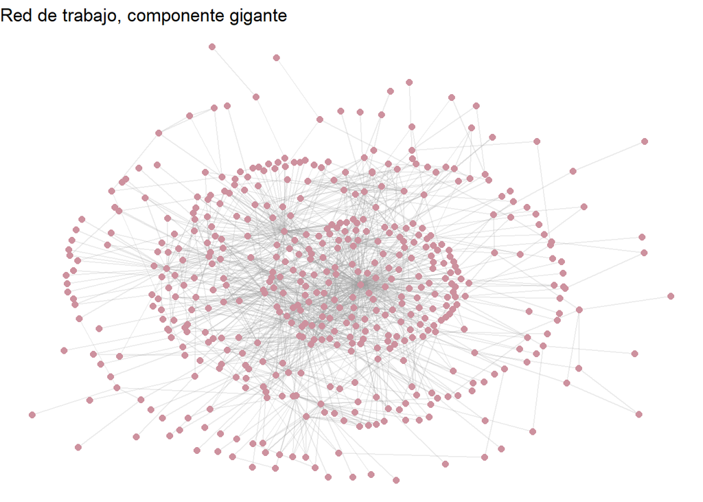

La red presenta una estructura fragmentada, compuesta por una componente gigante y varias componentes pequeñas. esto nos indica que la red esta fragamentada, sin embargo, dentro de la componente gigante se observa una mayor cohesión estructural en comparación con las subcomponentes periféricas, lo que sugiere una mayor integración interna de los actores principales. Esta estructura es consistente con un patrón de tipo núcleo–periferia, donde un grupo central altamente conectado concentra la mayor parte de las interacciones.

#### Conectividad

Resultados

| Medidas | Valores |
| --- | --- |
| ¿Está conectado | FALSE |
| Conectivdidad nodal | 0 |
| Conectividad por aristas | 0 |
| Puntos de artículación | gina-parody-d-echeona;juan-lozano-ramirez;simon-gaviria-munoz;daniel-quintero-calle;horacio-serpa-uribe;manuel-rodriguez-becerra;santiago-montenegro-trujillo;luis-alfonso-escobar-jaramillo;rodrigo-gue… |

Al igual que en la red de alianzas se identifica un conjunto amplio de nodos con potencial rol de articulación estructural dentro de la redlo que sugiere que la conectividad global no depende de un único nodo crítico, indicando una red con fragilidad estructural moderada, en la cual la eliminación de ciertos actores podría incrementar significativamente la fragmentación del sistema.

#### Agrupamiento

[figure not shown]

La transitividad local presenta una moda igual a cero, lo que indica que la mayoría de los nodos tienen vecinos que no tienden a estar conectados entre sí. A nivel global, la transitividad de la red (0.099) es baja, lo que indica una limitada formación de interacción entre 3 personas.

A continuación se hizo visualizaciones de las agrupaciones de nodos no aislados y no parejas, por el que fue el mejor algoritmo, **Fast Greedy**, en distintos gráficos, esto no significa que no esten conectadas entre sí estas agrupaciones, y si hizo esto netamente para una mejor visualización

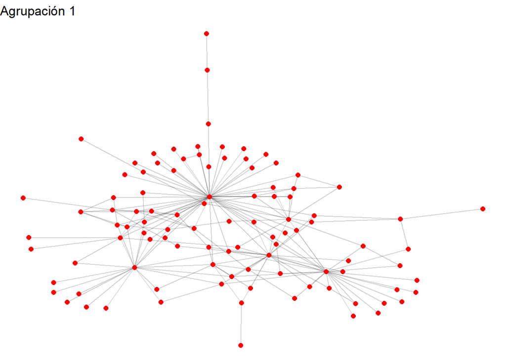

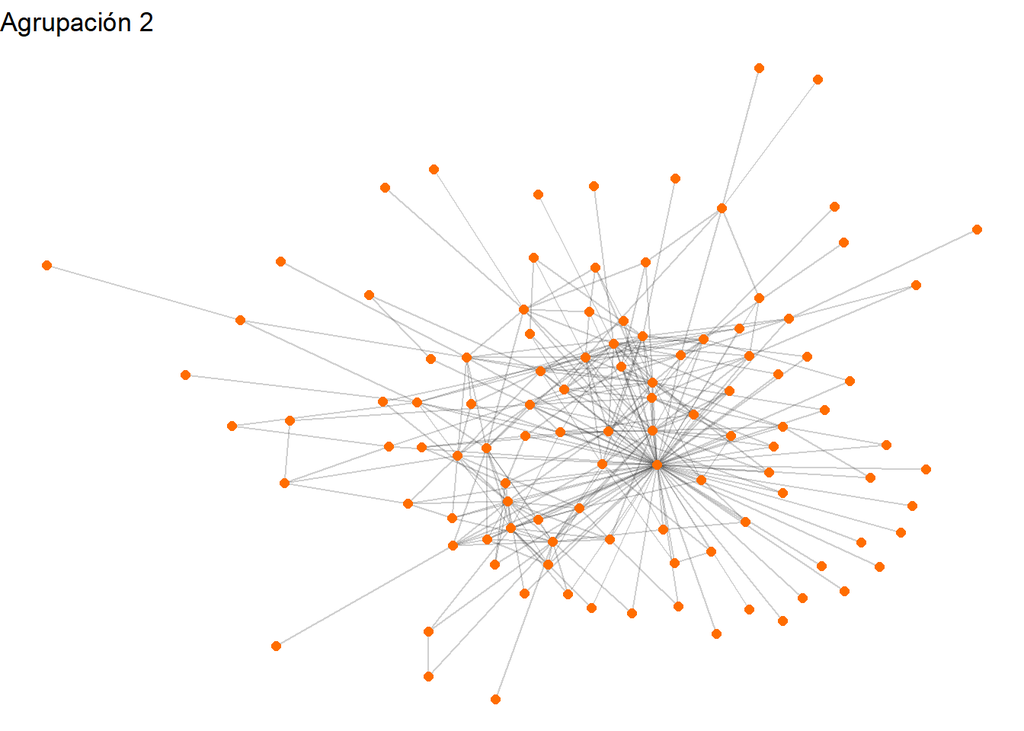

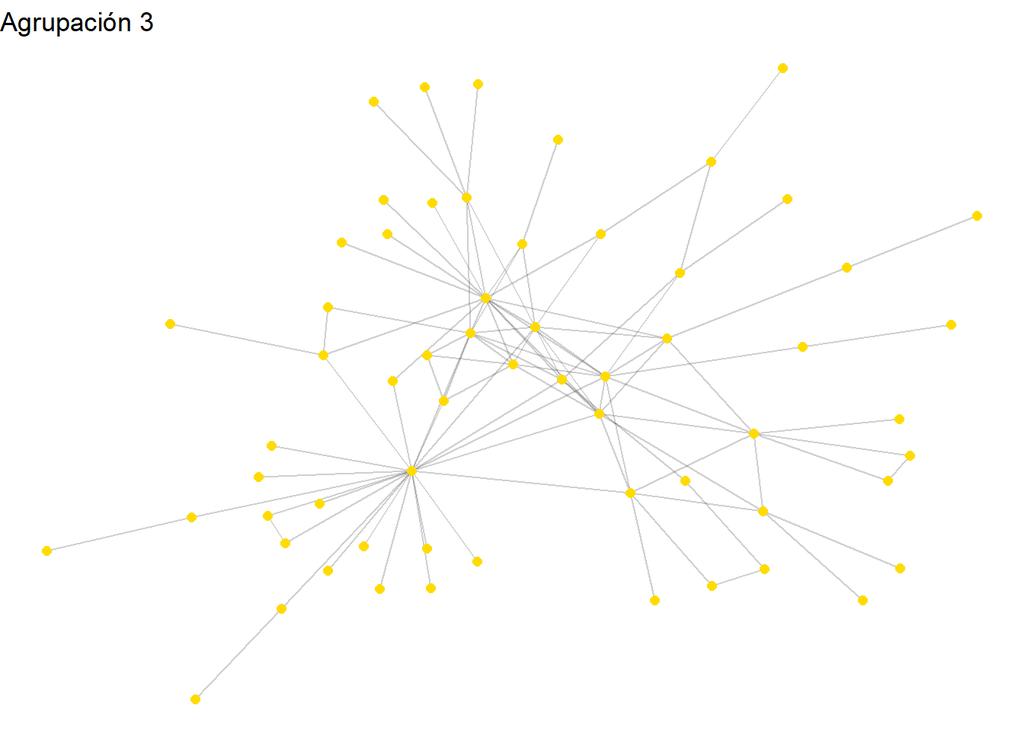

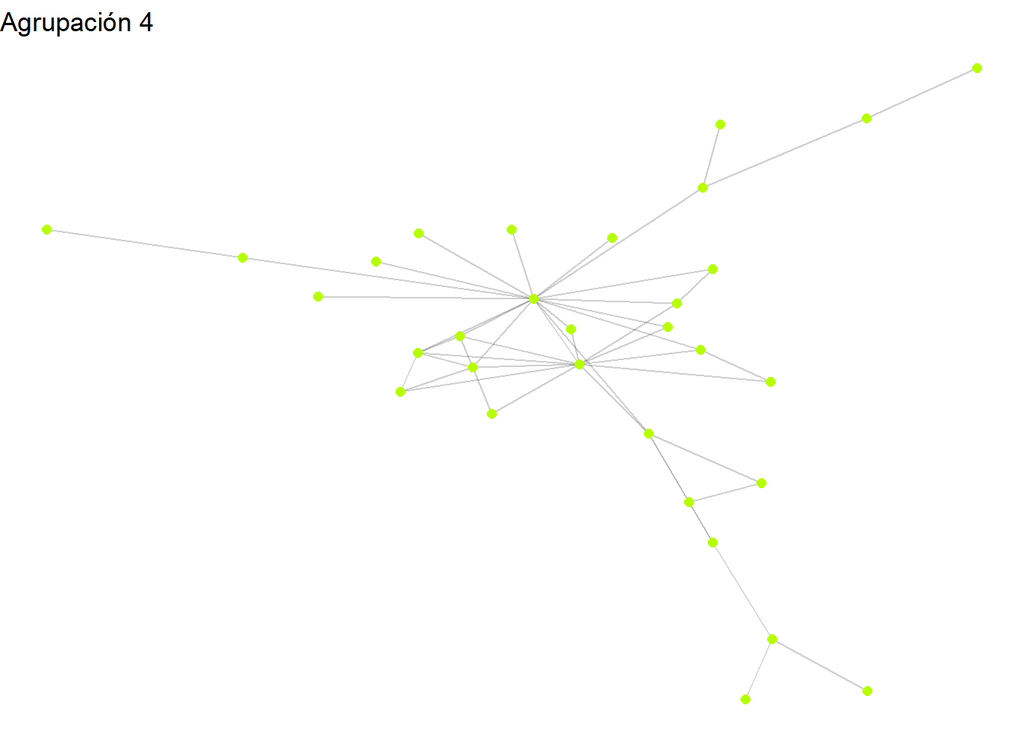

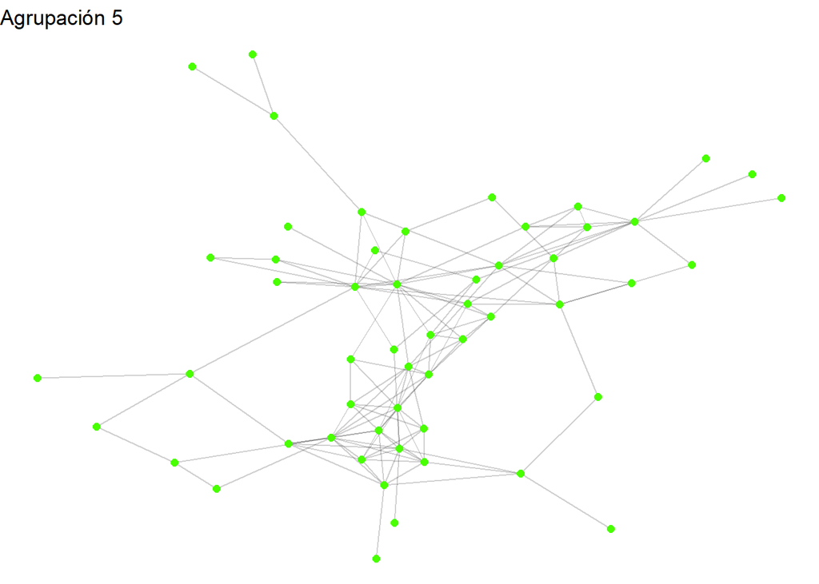

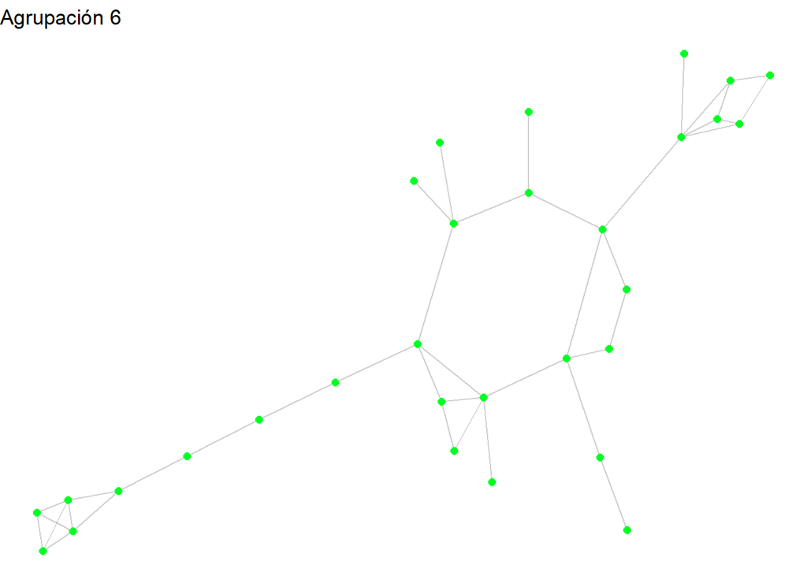

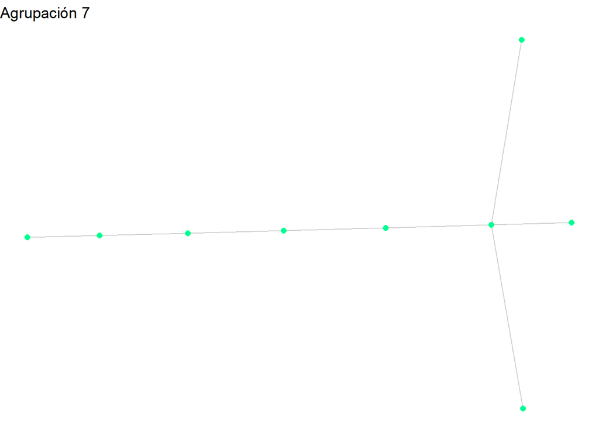

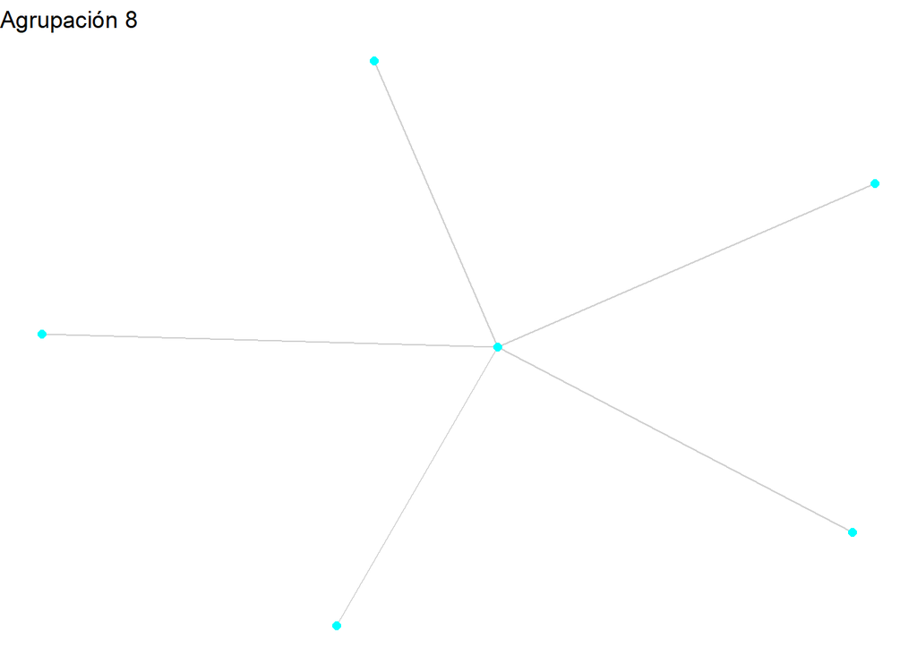